# 기말대체과제

```python
import pandas as pd
import matplotlib.pyplot as plt
```

### 데이터셋 설명

평균기온이 가장 높은 대구광역시와 평균기온이 가장 낮은 강원도의 지역별 평균기온, 최저기온, 최고기온, 일강수량, 최대 풍속, 평균 풍속, 평균 상대습도, 평균 지면온도와 추가한 일교차에 대한 2020년 일별 데이터가 정리된 데이터셋이다.

#### 기존 데이터셋

[figure not shown]

#### 전처리 후 데이터셋

[figure not shown]

#### 데이터 setting

```python
data = pd.read_csv('location_temperature.csv')
```

##### 동해

```python
donghe = data[(data['지역'] == '동해')]

jan = donghe[donghe['날짜'].str.contains('2020-01')]
donghe_avg_jan = round(sum(jan['평균기온(°C)']) / len(jan), 2)
donghe_min_jan = round(sum(jan['최저기온(°C)']) / len(jan), 2)
donghe_max_jan = round(sum(jan['최고기온(°C)']) / len(jan), 2)
feb = donghe[donghe['날짜'].str.contains('2020-02')]
donghe_avg_feb = round(sum(feb['평균기온(°C)']) / len(feb), 2)
donghe_min_feb = round(sum(feb['최저기온(°C)']) / len(feb), 2)
donghe_max_feb = round(sum(feb['최고기온(°C)']) / len(feb), 2)
mar = donghe[donghe['날짜'].str.contains('2020-03')]
donghe_avg_mar = round(sum(mar['평균기온(°C)']) / len(mar), 2)
donghe_min_mar = round(sum(mar['최저기온(°C)']) / len(mar), 2)
donghe_max_mar = round(sum(mar['최고기온(°C)']) / len(mar), 2)
apr = donghe[donghe['날짜'].str.contains('2020-04')]
donghe_avg_apr = round(sum(apr['평균기온(°C)']) / len(apr), 2)
donghe_min_apr = round(sum(apr['최저기온(°C)']) / len(apr), 2)
donghe_max_apr = round(sum(apr['최고기온(°C)']) / len(apr), 2)
may = donghe[donghe['날짜'].str.contains('2020-05')]
donghe_avg_may = round(sum(may['평균기온(°C)']) / len(may), 2)
donghe_min_may = round(sum(may['최저기온(°C)']) / len(may), 2)
donghe_max_may = round(sum(may['최고기온(°C)']) / len(may), 2)
jun = donghe[donghe['날짜'].str.contains('2020-06')]
donghe_avg_jun = round(sum(jun['평균기온(°C)']) / len(jun), 2)
donghe_min_jun = round(sum(jun['최저기온(°C)']) / len(jun), 2)
donghe_max_jun = round(sum(jun['최고기온(°C)']) / len(jun), 2)
jul = donghe[donghe['날짜'].str.contains('2020-07')]
donghe_avg_jul = round(sum(jul['평균기온(°C)']) / len(jul), 2)
donghe_min_jul = round(sum(jul['최저기온(°C)']) / len(jul), 2)
donghe_max_jul = round(sum(jul['최고기온(°C)']) / len(jul), 2)
aug = donghe[donghe['날짜'].str.contains('2020-08')]
donghe_avg_aug = round(sum(aug['평균기온(°C)']) / len(aug), 2)
donghe_min_aug = round(sum(aug['최저기온(°C)']) / len(aug), 2)
donghe_max_aug = round(sum(aug['최고기온(°C)']) / len(aug), 2)
sep = donghe[donghe['날짜'].str.contains('2020-09')]
donghe_avg_sep = round(sum(sep['평균기온(°C)']) / len(sep), 2)
donghe_min_sep = round(sum(sep['최저기온(°C)']) / len(sep), 2)
donghe_max_sep = round(sum(sep['최고기온(°C)']) / len(sep), 2)
oco = donghe[donghe['날짜'].str.contains('2020-10')]
donghe_avg_oco = round(sum(oco['평균기온(°C)']) / len(oco), 2)
donghe_min_oco = round(sum(oco['최저기온(°C)']) / len(oco), 2)
donghe_max_oco = round(sum(oco['최고기온(°C)']) / len(oco), 2)
nov = donghe[donghe['날짜'].str.contains('2020-11')]
donghe_avg_nov = round(sum(nov['평균기온(°C)']) / len(nov), 2)
donghe_min_nov = round(sum(nov['최저기온(°C)']) / len(nov), 2)
donghe_max_nov = round(sum(nov['최고기온(°C)']) / len(nov), 2)
dec = donghe[donghe['날짜'].str.contains('2020-12')]
donghe_avg_dec = round(sum(dec['평균기온(°C)']) / len(dec), 2)
donghe_min_dec = round(sum(dec['최저기온(°C)']) / len(dec), 2)
donghe_max_dec = round(sum(dec['최고기온(°C)']) / len(dec), 2)
```

##### 대관령

```python
daegwallyeong = data[(data['지역'] == '대관령')]

jan = daegwallyeong[daegwallyeong['날짜'].str.contains('2020-01')]
daegwallyeong_avg_jan = round(sum(jan['평균기온(°C)']) / len(jan), 2)
daegwallyeong_min_jan = round(sum(jan['최저기온(°C)']) / len(jan), 2)
daegwallyeong_max_jan = round(sum(jan['최고기온(°C)']) / len(jan), 2)
feb = daegwallyeong[daegwallyeong['날짜'].str.contains('2020-02')]
daegwallyeong_avg_feb = round(sum(feb['평균기온(°C)']) / len(feb), 2)
daegwallyeong_min_feb = round(sum(feb['최저기온(°C)']) / len(feb), 2)
daegwallyeong_max_feb = round(sum(feb['최고기온(°C)']) / len(feb), 2)
mar = daegwallyeong[daegwallyeong['날짜'].str.contains('2020-03')]
daegwallyeong_avg_mar = round(sum(mar['평균기온(°C)']) / len(mar), 2)
daegwallyeong_min_mar = round(sum(mar['최저기온(°C)']) / len(mar), 2)
daegwallyeong_max_mar = round(sum(mar['최고기온(°C)']) / len(mar), 2)
apr = daegwallyeong[daegwallyeong['날짜'].str.contains('2020-04')]
daegwallyeong_avg_apr = round(sum(apr['평균기온(°C)']) / len(apr), 2)
daegwallyeong_min_apr = round(sum(apr['최저기온(°C)']) / len(apr), 2)
daegwallyeong_max_apr = round(sum(apr['최고기온(°C)']) / len(apr), 2)
may = daegwallyeong[daegwallyeong['날짜'].str.contains('2020-05')]
daegwallyeong_avg_may = round(sum(may['평균기온(°C)']) / len(may), 2)
daegwallyeong_min_may = round(sum(may['최저기온(°C)']) / len(may), 2)
daegwallyeong_max_may = round(sum(may['최고기온(°C)']) / len(may), 2)
jun = daegwallyeong[daegwallyeong['날짜'].str.contains('2020-06')]
daegwallyeong_avg_jun = round(sum(jun['평균기온(°C)']) / len(jun), 2)
daegwallyeong_min_jun = round(sum(jun['최저기온(°C)']) / len(jun), 2)
daegwallyeong_max_jun = round(sum(jun['최고기온(°C)']) / len(jun), 2)
jul = daegwallyeong[daegwallyeong['날짜'].str.contains('2020-07')]
daegwallyeong_avg_jul = round(sum(jul['평균기온(°C)']) / len(jul), 2)
daegwallyeong_min_jul = round(sum(jul['최저기온(°C)']) / len(jul), 2)
daegwallyeong_max_jul = round(sum(jul['최고기온(°C)']) / len(jul), 2)
aug = daegwallyeong[daegwallyeong['날짜'].str.contains('2020-08')]
daegwallyeong_avg_aug = round(sum(aug['평균기온(°C)']) / len(aug), 2)
daegwallyeong_min_aug = round(sum(aug['최저기온(°C)']) / len(aug), 2)
daegwallyeong_max_aug = round(sum(aug['최고기온(°C)']) / len(aug), 2)
sep = daegwallyeong[daegwallyeong['날짜'].str.contains('2020-09')]
daegwallyeong_avg_sep = round(sum(sep['평균기온(°C)']) / len(sep), 2)
daegwallyeong_min_sep = round(sum(sep['최저기온(°C)']) / len(sep), 2)
daegwallyeong_max_sep = round(sum(sep['최고기온(°C)']) / len(sep), 2)
oco = daegwallyeong[daegwallyeong['날짜'].str.contains('2020-10')]
daegwallyeong_avg_oco = round(sum(oco['평균기온(°C)']) / len(oco), 2)
daegwallyeong_min_oco = round(sum(oco['최저기온(°C)']) / len(oco), 2)
daegwallyeong_max_oco = round(sum(oco['최고기온(°C)']) / len(oco), 2)
nov = daegwallyeong[daegwallyeong['날짜'].str.contains('2020-11')]
daegwallyeong_avg_nov = round(sum(nov['평균기온(°C)']) / len(nov), 2)
daegwallyeong_min_nov = round(sum(nov['최저기온(°C)']) / len(nov), 2)
daegwallyeong_max_nov = round(sum(nov['최고기온(°C)']) / len(nov), 2)
dec = daegwallyeong[daegwallyeong['날짜'].str.contains('2020-12')]
daegwallyeong_avg_dec = round(sum(dec['평균기온(°C)']) / len(dec), 2)
daegwallyeong_min_dec = round(sum(dec['최저기온(°C)']) / len(dec), 2)
daegwallyeong_max_dec = round(sum(dec['최고기온(°C)']) / len(dec), 2)
```

##### 강릉

```python
gangneung = data[(data['지역'] == '강릉')]

jan = gangneung[gangneung['날짜'].str.contains('2020-01')]
gangneung_avg_jan = round(sum(jan['평균기온(°C)']) / len(jan), 2)
gangneung_min_jan = round(sum(jan['최저기온(°C)']) / len(jan), 2)
gangneung_max_jan = round(sum(jan['최고기온(°C)']) / len(jan), 2)
feb = gangneung[gangneung['날짜'].str.contains('2020-02')]
gangneung_avg_feb = round(sum(feb['평균기온(°C)']) / len(feb), 2)
gangneung_min_feb = round(sum(feb['최저기온(°C)']) / len(feb), 2)
gangneung_max_feb = round(sum(feb['최고기온(°C)']) / len(feb), 2)
mar = gangneung[gangneung['날짜'].str.contains('2020-03')]
gangneung_avg_mar = round(sum(mar['평균기온(°C)']) / len(mar), 2)
gangneung_min_mar = round(sum(mar['최저기온(°C)']) / len(mar), 2)
gangneung_max_mar = round(sum(mar['최고기온(°C)']) / len(mar), 2)
apr = gangneung[gangneung['날짜'].str.contains('2020-04')]
gangneung_avg_apr = round(sum(apr['평균기온(°C)']) / len(apr), 2)
gangneung_min_apr = round(sum(apr['최저기온(°C)']) / len(apr), 2)
gangneung_max_apr = round(sum(apr['최고기온(°C)']) / len(apr), 2)
may = gangneung[gangneung['날짜'].str.contains('2020-05')]
gangneung_avg_may = round(sum(may['평균기온(°C)']) / len(may), 2)
gangneung_min_may = round(sum(may['최저기온(°C)']) / len(may), 2)
gangneung_max_may = round(sum(may['최고기온(°C)']) / len(may), 2)
jun = gangneung[gangneung['날짜'].str.contains('2020-06')]
gangneung_avg_jun = round(sum(jun['평균기온(°C)']) / len(jun), 2)
gangneung_min_jun = round(sum(jun['최저기온(°C)']) / len(jun), 2)
gangneung_max_jun = round(sum(jun['최고기온(°C)']) / len(jun), 2)
jul = gangneung[gangneung['날짜'].str.contains('2020-07')]
gangneung_avg_jul = round(sum(jul['평균기온(°C)']) / len(jul), 2)
gangneung_min_jul = round(sum(jul['최저기온(°C)']) / len(jul), 2)
gangneung_max_jul = round(sum(jul['최고기온(°C)']) / len(jul), 2)
aug = gangneung[gangneung['날짜'].str.contains('2020-08')]
gangneung_avg_aug = round(sum(aug['평균기온(°C)']) / len(aug), 2)
gangneung_min_aug = round(sum(aug['최저기온(°C)']) / len(aug), 2)
gangneung_max_aug = round(sum(aug['최고기온(°C)']) / len(aug), 2)
sep = gangneung[gangneung['날짜'].str.contains('2020-09')]
gangneung_avg_sep = round(sum(sep['평균기온(°C)']) / len(sep), 2)
gangneung_min_sep = round(sum(sep['최저기온(°C)']) / len(sep), 2)
gangneung_max_sep = round(sum(sep['최고기온(°C)']) / len(sep), 2)
oco = gangneung[gangneung['날짜'].str.contains('2020-10')]
gangneung_avg_oco = round(sum(oco['평균기온(°C)']) / len(oco), 2)
gangneung_min_oco = round(sum(oco['최저기온(°C)']) / len(oco), 2)
gangneung_max_oco = round(sum(oco['최고기온(°C)']) / len(oco), 2)
nov = gangneung[gangneung['날짜'].str.contains('2020-11')]
gangneung_avg_nov = round(sum(nov['평균기온(°C)']) / len(nov), 2)
gangneung_min_nov = round(sum(nov['최저기온(°C)']) / len(nov), 2)
gangneung_max_nov = round(sum(nov['최고기온(°C)']) / len(nov), 2)
dec = gangneung[gangneung['날짜'].str.contains('2020-12')]
gangneung_avg_dec = round(sum(dec['평균기온(°C)']) / len(dec), 2)
gangneung_min_dec = round(sum(dec['최저기온(°C)']) / len(dec), 2)
gangneung_max_dec = round(sum(dec['최고기온(°C)']) / len(dec), 2)
```

##### 북강릉

```python
bukgangneung = data[(data['지역'] == '북강릉')]

jan = bukgangneung[bukgangneung['날짜'].str.contains('2020-01')]
bukgangneung_avg_jan = round(sum(jan['평균기온(°C)']) / len(jan), 2)
bukgangneung_min_jan = round(sum(jan['최저기온(°C)']) / len(jan), 2)
bukgangneung_max_jan = round(sum(jan['최고기온(°C)']) / len(jan), 2)
feb = bukgangneung[bukgangneung['날짜'].str.contains('2020-02')]
bukgangneung_avg_feb = round(sum(feb['평균기온(°C)']) / len(feb), 2)
bukgangneung_min_feb = round(sum(feb['최저기온(°C)']) / len(feb), 2)
bukgangneung_max_feb = round(sum(feb['최고기온(°C)']) / len(feb), 2)
mar = bukgangneung[bukgangneung['날짜'].str.contains('2020-03')]
bukgangneung_avg_mar = round(sum(mar['평균기온(°C)']) / len(mar), 2)
bukgangneung_min_mar = round(sum(mar['최저기온(°C)']) / len(mar), 2)
bukgangneung_max_mar = round(sum(mar['최고기온(°C)']) / len(mar), 2)
apr = bukgangneung[bukgangneung['날짜'].str.contains('2020-04')]
bukgangneung_avg_apr = round(sum(apr['평균기온(°C)']) / len(apr), 2)
bukgangneung_min_apr = round(sum(apr['최저기온(°C)']) / len(apr), 2)
bukgangneung_max_apr = round(sum(apr['최고기온(°C)']) / len(apr), 2)
may = bukgangneung[bukgangneung['날짜'].str.contains('2020-05')]
bukgangneung_avg_may = round(sum(may['평균기온(°C)']) / len(may), 2)
bukgangneung_min_may = round(sum(may['최저기온(°C)']) / len(may), 2)
bukgangneung_max_may = round(sum(may['최고기온(°C)']) / len(may), 2)
jun = bukgangneung[bukgangneung['날짜'].str.contains('2020-06')]
bukgangneung_avg_jun = round(sum(jun['평균기온(°C)']) / len(jun), 2)
bukgangneung_min_jun = round(sum(jun['최저기온(°C)']) / len(jun), 2)
bukgangneung_max_jun = round(sum(jun['최고기온(°C)']) / len(jun), 2)
jul = bukgangneung[bukgangneung['날짜'].str.contains('2020-07')]
bukgangneung_avg_jul = round(sum(jul['평균기온(°C)']) / len(jul), 2)
bukgangneung_min_jul = round(sum(jul['최저기온(°C)']) / len(jul), 2)
bukgangneung_max_jul = round(sum(jul['최고기온(°C)']) / len(jul), 2)
aug = bukgangneung[bukgangneung['날짜'].str.contains('2020-08')]
bukgangneung_avg_aug = round(sum(aug['평균기온(°C)']) / len(aug), 2)
bukgangneung_min_aug = round(sum(aug['최저기온(°C)']) / len(aug), 2)
bukgangneung_max_aug = round(sum(aug['최고기온(°C)']) / len(aug), 2)
sep = bukgangneung[bukgangneung['날짜'].str.contains('2020-09')]
bukgangneung_avg_sep = round(sum(sep['평균기온(°C)']) / len(sep), 2)
bukgangneung_min_sep = round(sum(sep['최저기온(°C)']) / len(sep), 2)
bukgangneung_max_sep = round(sum(sep['최고기온(°C)']) / len(sep), 2)
oco = bukgangneung[bukgangneung['날짜'].str.contains('2020-10')]
bukgangneung_avg_oco = round(sum(oco['평균기온(°C)']) / len(oco), 2)
bukgangneung_min_oco = round(sum(oco['최저기온(°C)']) / len(oco), 2)
bukgangneung_max_oco = round(sum(oco['최고기온(°C)']) / len(oco), 2)
nov = bukgangneung[bukgangneung['날짜'].str.contains('2020-11')]
bukgangneung_avg_nov = round(sum(nov['평균기온(°C)']) / len(nov), 2)
bukgangneung_min_nov = round(sum(nov['최저기온(°C)']) / len(nov), 2)
bukgangneung_max_nov = round(sum(nov['최고기온(°C)']) / len(nov), 2)
dec = bukgangneung[bukgangneung['날짜'].str.contains('2020-12')]
bukgangneung_avg_dec = round(sum(dec['평균기온(°C)']) / len(dec), 2)
bukgangneung_min_dec = round(sum(dec['최저기온(°C)']) / len(dec), 2)
bukgangneung_max_dec = round(sum(dec['최고기온(°C)']) / len(dec), 2)
```

##### 춘천

```python
chuncheon = data[(data['지역'] == '춘천')]

jan = chuncheon[chuncheon['날짜'].str.contains('2020-01')]
chuncheon_avg_jan = round(sum(jan['평균기온(°C)']) / len(jan), 2)
chuncheon_min_jan = round(sum(jan['최저기온(°C)']) / len(jan), 2)
chuncheon_max_jan = round(sum(jan['최고기온(°C)']) / len(jan), 2)
feb = chuncheon[chuncheon['날짜'].str.contains('2020-02')]
chuncheon_avg_feb = round(sum(feb['평균기온(°C)']) / len(feb), 2)
chuncheon_min_feb = round(sum(feb['최저기온(°C)']) / len(feb), 2)
chuncheon_max_feb = round(sum(feb['최고기온(°C)']) / len(feb), 2)
mar = chuncheon[chuncheon['날짜'].str.contains('2020-03')]
chuncheon_avg_mar = round(sum(mar['평균기온(°C)']) / len(mar), 2)
chuncheon_min_mar = round(sum(mar['최저기온(°C)']) / len(mar), 2)
chuncheon_max_mar = round(sum(mar['최고기온(°C)']) / len(mar), 2)
apr = chuncheon[chuncheon['날짜'].str.contains('2020-04')]
chuncheon_avg_apr = round(sum(apr['평균기온(°C)']) / len(apr), 2)
chuncheon_min_apr = round(sum(apr['최저기온(°C)']) / len(apr), 2)
chuncheon_max_apr = round(sum(apr['최고기온(°C)']) / len(apr), 2)
may = chuncheon[chuncheon['날짜'].str.contains('2020-05')]
chuncheon_avg_may = round(sum(may['평균기온(°C)']) / len(may), 2)
chuncheon_min_may = round(sum(may['최저기온(°C)']) / len(may), 2)
chuncheon_max_may = round(sum(may['최고기온(°C)']) / len(may), 2)
jun = chuncheon[chuncheon['날짜'].str.contains('2020-06')]
chuncheon_avg_jun = round(sum(jun['평균기온(°C)']) / len(jun), 2)
chuncheon_min_jun = round(sum(jun['최저기온(°C)']) / len(jun), 2)
chuncheon_max_jun = round(sum(jun['최고기온(°C)']) / len(jun), 2)
jul = chuncheon[chuncheon['날짜'].str.contains('2020-07')]
chuncheon_avg_jul = round(sum(jul['평균기온(°C)']) / len(jul), 2)
chuncheon_min_jul = round(sum(jul['최저기온(°C)']) / len(jul), 2)
chuncheon_max_jul = round(sum(jul['최고기온(°C)']) / len(jul), 2)
aug = chuncheon[chuncheon['날짜'].str.contains('2020-08')]
chuncheon_avg_aug = round(sum(aug['평균기온(°C)']) / len(aug), 2)
chuncheon_min_aug = round(sum(aug['최저기온(°C)']) / len(aug), 2)
chuncheon_max_aug = round(sum(aug['최고기온(°C)']) / len(aug), 2)
sep = chuncheon[chuncheon['날짜'].str.contains('2020-09')]
chuncheon_avg_sep = round(sum(sep['평균기온(°C)']) / len(sep), 2)
chuncheon_min_sep = round(sum(sep['최저기온(°C)']) / len(sep), 2)
chuncheon_max_sep = round(sum(sep['최고기온(°C)']) / len(sep), 2)
oco = chuncheon[chuncheon['날짜'].str.contains('2020-10')]
chuncheon_avg_oco = round(sum(oco['평균기온(°C)']) / len(oco), 2)
chuncheon_min_oco = round(sum(oco['최저기온(°C)']) / len(oco), 2)
chuncheon_max_oco = round(sum(oco['최고기온(°C)']) / len(oco), 2)
nov = chuncheon[chuncheon['날짜'].str.contains('2020-11')]
chuncheon_avg_nov = round(sum(nov['평균기온(°C)']) / len(nov), 2)
chuncheon_min_nov = round(sum(nov['최저기온(°C)']) / len(nov), 2)
chuncheon_max_nov = round(sum(nov['최고기온(°C)']) / len(nov), 2)
dec = chuncheon[chuncheon['날짜'].str.contains('2020-12')]
chuncheon_avg_dec = round(sum(dec['평균기온(°C)']) / len(dec), 2)
chuncheon_min_dec = round(sum(dec['최저기온(°C)']) / len(dec), 2)
chuncheon_max_dec = round(sum(dec['최고기온(°C)']) / len(dec), 2)
```

##### 북춘천

```python
bukchuncheon = data[(data['지역'] == '북춘천')]

jan = bukchuncheon[bukchuncheon['날짜'].str.contains('2020-01')]
bukchuncheon_avg_jan = round(sum(jan['평균기온(°C)']) / len(jan), 2)
bukchuncheon_min_jan = round(sum(jan['최저기온(°C)']) / len(jan), 2)
bukchuncheon_max_jan = round(sum(jan['최고기온(°C)']) / len(jan), 2)
feb = bukchuncheon[bukchuncheon['날짜'].str.contains('2020-02')]
bukchuncheon_avg_feb = round(sum(feb['평균기온(°C)']) / len(feb), 2)
bukchuncheon_min_feb = round(sum(feb['최저기온(°C)']) / len(feb), 2)
bukchuncheon_max_feb = round(sum(feb['최고기온(°C)']) / len(feb), 2)
mar = bukchuncheon[bukchuncheon['날짜'].str.contains('2020-03')]
bukchuncheon_avg_mar = round(sum(mar['평균기온(°C)']) / len(mar), 2)
bukchuncheon_min_mar = round(sum(mar['최저기온(°C)']) / len(mar), 2)
bukchuncheon_max_mar = round(sum(mar['최고기온(°C)']) / len(mar), 2)
apr = bukchuncheon[bukchuncheon['날짜'].str.contains('2020-04')]
bukchuncheon_avg_apr = round(sum(apr['평균기온(°C)']) / len(apr), 2)
bukchuncheon_min_apr = round(sum(apr['최저기온(°C)']) / len(apr), 2)
bukchuncheon_max_apr = round(sum(apr['최고기온(°C)']) / len(apr), 2)
may = bukchuncheon[bukchuncheon['날짜'].str.contains('2020-05')]
bukchuncheon_avg_may = round(sum(may['평균기온(°C)']) / len(may), 2)
bukchuncheon_min_may = round(sum(may['최저기온(°C)']) / len(may), 2)
bukchuncheon_max_may = round(sum(may['최고기온(°C)']) / len(may), 2)
jun = bukchuncheon[bukchuncheon['날짜'].str.contains('2020-06')]
bukchuncheon_avg_jun = round(sum(jun['평균기온(°C)']) / len(jun), 2)
bukchuncheon_min_jun = round(sum(jun['최저기온(°C)']) / len(jun), 2)
bukchuncheon_max_jun = round(sum(jun['최고기온(°C)']) / len(jun), 2)
jul = bukchuncheon[bukchuncheon['날짜'].str.contains('2020-07')]
bukchuncheon_avg_jul = round(sum(jul['평균기온(°C)']) / len(jul), 2)
bukchuncheon_min_jul = round(sum(jul['최저기온(°C)']) / len(jul), 2)
bukchuncheon_max_jul = round(sum(jul['최고기온(°C)']) / len(jul), 2)
aug = bukchuncheon[bukchuncheon['날짜'].str.contains('2020-08')]
bukchuncheon_avg_aug = round(sum(aug['평균기온(°C)']) / len(aug), 2)
bukchuncheon_min_aug = round(sum(aug['최저기온(°C)']) / len(aug), 2)
bukchuncheon_max_aug = round(sum(aug['최고기온(°C)']) / len(aug), 2)
sep = bukchuncheon[bukchuncheon['날짜'].str.contains('2020-09')]
bukchuncheon_avg_sep = round(sum(sep['평균기온(°C)']) / len(sep), 2)
bukchuncheon_min_sep = round(sum(sep['최저기온(°C)']) / len(sep), 2)
bukchuncheon_max_sep = round(sum(sep['최고기온(°C)']) / len(sep), 2)
oco = bukchuncheon[bukchuncheon['날짜'].str.contains('2020-10')]
bukchuncheon_avg_oco = round(sum(oco['평균기온(°C)']) / len(oco), 2)
bukchuncheon_min_oco = round(sum(oco['최저기온(°C)']) / len(oco), 2)
bukchuncheon_max_oco = round(sum(oco['최고기온(°C)']) / len(oco), 2)
nov = bukchuncheon[bukchuncheon['날짜'].str.contains('2020-11')]
bukchuncheon_avg_nov = round(sum(nov['평균기온(°C)']) / len(nov), 2)
bukchuncheon_min_nov = round(sum(nov['최저기온(°C)']) / len(nov), 2)
bukchuncheon_max_nov = round(sum(nov['최고기온(°C)']) / len(nov), 2)
dec = bukchuncheon[bukchuncheon['날짜'].str.contains('2020-12')]
bukchuncheon_avg_dec = round(sum(dec['평균기온(°C)']) / len(dec), 2)
bukchuncheon_min_dec = round(sum(dec['최저기온(°C)']) / len(dec), 2)
bukchuncheon_max_dec = round(sum(dec['최고기온(°C)']) / len(dec), 2)
```

##### 홍천

```python
hongcheon = data[(data['지역'] == '홍천')]

jan = hongcheon[hongcheon['날짜'].str.contains('2020-01')]
hongcheon_avg_jan = round(sum(jan['평균기온(°C)']) / len(jan), 2)
hongcheon_min_jan = round(sum(jan['최저기온(°C)']) / len(jan), 2)
hongcheon_max_jan = round(sum(jan['최고기온(°C)']) / len(jan), 2)
feb = hongcheon[hongcheon['날짜'].str.contains('2020-02')]
hongcheon_avg_feb = round(sum(feb['평균기온(°C)']) / len(feb), 2)
hongcheon_min_feb = round(sum(feb['최저기온(°C)']) / len(feb), 2)
hongcheon_max_feb = round(sum(feb['최고기온(°C)']) / len(feb), 2)
mar = hongcheon[hongcheon['날짜'].str.contains('2020-03')]
hongcheon_avg_mar = round(sum(mar['평균기온(°C)']) / len(mar), 2)
hongcheon_min_mar = round(sum(mar['최저기온(°C)']) / len(mar), 2)
hongcheon_max_mar = round(sum(mar['최고기온(°C)']) / len(mar), 2)
apr = hongcheon[hongcheon['날짜'].str.contains('2020-04')]
hongcheon_avg_apr = round(sum(apr['평균기온(°C)']) / len(apr), 2)
hongcheon_min_apr = round(sum(apr['최저기온(°C)']) / len(apr), 2)
hongcheon_max_apr = round(sum(apr['최고기온(°C)']) / len(apr), 2)
may = hongcheon[hongcheon['날짜'].str.contains('2020-05')]
hongcheon_avg_may = round(sum(may['평균기온(°C)']) / len(may), 2)
hongcheon_min_may = round(sum(may['최저기온(°C)']) / len(may), 2)
hongcheon_max_may = round(sum(may['최고기온(°C)']) / len(may), 2)
jun = hongcheon[hongcheon['날짜'].str.contains('2020-06')]
hongcheon_avg_jun = round(sum(jun['평균기온(°C)']) / len(jun), 2)
hongcheon_min_jun = round(sum(jun['최저기온(°C)']) / len(jun), 2)
hongcheon_max_jun = round(sum(jun['최고기온(°C)']) / len(jun), 2)
jul = hongcheon[hongcheon['날짜'].str.contains('2020-07')]
hongcheon_avg_jul = round(sum(jul['평균기온(°C)']) / len(jul), 2)
hongcheon_min_jul = round(sum(jul['최저기온(°C)']) / len(jul), 2)
hongcheon_max_jul = round(sum(jul['최고기온(°C)']) / len(jul), 2)
aug = hongcheon[hongcheon['날짜'].str.contains('2020-08')]
hongcheon_avg_aug = round(sum(aug['평균기온(°C)']) / len(aug), 2)
hongcheon_min_aug = round(sum(aug['최저기온(°C)']) / len(aug), 2)
hongcheon_max_aug = round(sum(aug['최고기온(°C)']) / len(aug), 2)
sep = hongcheon[hongcheon['날짜'].str.contains('2020-09')]
hongcheon_avg_sep = round(sum(sep['평균기온(°C)']) / len(sep), 2)
hongcheon_min_sep = round(sum(sep['최저기온(°C)']) / len(sep), 2)
hongcheon_max_sep = round(sum(sep['최고기온(°C)']) / len(sep), 2)
oco = hongcheon[hongcheon['날짜'].str.contains('2020-10')]
hongcheon_avg_oco = round(sum(oco['평균기온(°C)']) / len(oco), 2)
hongcheon_min_oco = round(sum(oco['최저기온(°C)']) / len(oco), 2)
hongcheon_max_oco = round(sum(oco['최고기온(°C)']) / len(oco), 2)
nov = hongcheon[hongcheon['날짜'].str.contains('2020-11')]
hongcheon_avg_nov = round(sum(nov['평균기온(°C)']) / len(nov), 2)
hongcheon_min_nov = round(sum(nov['최저기온(°C)']) / len(nov), 2)
hongcheon_max_nov = round(sum(nov['최고기온(°C)']) / len(nov), 2)
dec = hongcheon[hongcheon['날짜'].str.contains('2020-12')]
hongcheon_avg_dec = round(sum(dec['평균기온(°C)']) / len(dec), 2)
hongcheon_min_dec = round(sum(dec['최저기온(°C)']) / len(dec), 2)
hongcheon_max_dec = round(sum(dec['최고기온(°C)']) / len(dec), 2)
```

##### 태백

```python
taebaek = data[(data['지역'] == '태백')]

jan = taebaek[taebaek['날짜'].str.contains('2020-01')]
taebaek_avg_jan = round(sum(jan['평균기온(°C)']) / len(jan), 2)
taebaek_min_jan = round(sum(jan['최저기온(°C)']) / len(jan), 2)
taebaek_max_jan = round(sum(jan['최고기온(°C)']) / len(jan), 2)
feb = taebaek[taebaek['날짜'].str.contains('2020-02')]
taebaek_avg_feb = round(sum(feb['평균기온(°C)']) / len(feb), 2)
taebaek_min_feb = round(sum(feb['최저기온(°C)']) / len(feb), 2)
taebaek_max_feb = round(sum(feb['최고기온(°C)']) / len(feb), 2)
mar = taebaek[taebaek['날짜'].str.contains('2020-03')]
taebaek_avg_mar = round(sum(mar['평균기온(°C)']) / len(mar), 2)
taebaek_min_mar = round(sum(mar['최저기온(°C)']) / len(mar), 2)
taebaek_max_mar = round(sum(mar['최고기온(°C)']) / len(mar), 2)
apr = taebaek[taebaek['날짜'].str.contains('2020-04')]
taebaek_avg_apr = round(sum(apr['평균기온(°C)']) / len(apr), 2)
taebaek_min_apr = round(sum(apr['최저기온(°C)']) / len(apr), 2)
taebaek_max_apr = round(sum(apr['최고기온(°C)']) / len(apr), 2)
may = taebaek[taebaek['날짜'].str.contains('2020-05')]
taebaek_avg_may = round(sum(may['평균기온(°C)']) / len(may), 2)
taebaek_min_may = round(sum(may['최저기온(°C)']) / len(may), 2)
taebaek_max_may = round(sum(may['최고기온(°C)']) / len(may), 2)
jun = taebaek[taebaek['날짜'].str.contains('2020-06')]
taebaek_avg_jun = round(sum(jun['평균기온(°C)']) / len(jun), 2)
taebaek_min_jun = round(sum(jun['최저기온(°C)']) / len(jun), 2)
taebaek_max_jun = round(sum(jun['최고기온(°C)']) / len(jun), 2)
jul = taebaek[taebaek['날짜'].str.contains('2020-07')]
taebaek_avg_jul = round(sum(jul['평균기온(°C)']) / len(jul), 2)
taebaek_min_jul = round(sum(jul['최저기온(°C)']) / len(jul), 2)
taebaek_max_jul = round(sum(jul['최고기온(°C)']) / len(jul), 2)
aug = taebaek[taebaek['날짜'].str.contains('2020-08')]
taebaek_avg_aug = round(sum(aug['평균기온(°C)']) / len(aug), 2)
taebaek_min_aug = round(sum(aug['최저기온(°C)']) / len(aug), 2)
taebaek_max_aug = round(sum(aug['최고기온(°C)']) / len(aug), 2)
sep = taebaek[taebaek['날짜'].str.contains('2020-09')]
taebaek_avg_sep = round(sum(sep['평균기온(°C)']) / len(sep), 2)
taebaek_min_sep = round(sum(sep['최저기온(°C)']) / len(sep), 2)
taebaek_max_sep = round(sum(sep['최고기온(°C)']) / len(sep), 2)
oco = taebaek[taebaek['날짜'].str.contains('2020-10')]
taebaek_avg_oco = round(sum(oco['평균기온(°C)']) / len(oco), 2)
taebaek_min_oco = round(sum(oco['최저기온(°C)']) / len(oco), 2)
taebaek_max_oco = round(sum(oco['최고기온(°C)']) / len(oco), 2)
nov = taebaek[taebaek['날짜'].str.contains('2020-11')]
taebaek_avg_nov = round(sum(nov['평균기온(°C)']) / len(nov), 2)
taebaek_min_nov = round(sum(nov['최저기온(°C)']) / len(nov), 2)
taebaek_max_nov = round(sum(nov['최고기온(°C)']) / len(nov), 2)
dec = taebaek[taebaek['날짜'].str.contains('2020-12')]
taebaek_avg_dec = round(sum(dec['평균기온(°C)']) / len(dec), 2)
taebaek_min_dec = round(sum(dec['최저기온(°C)']) / len(dec), 2)
taebaek_max_dec = round(sum(dec['최고기온(°C)']) / len(dec), 2)
```

##### 철원

```python
cheorwon = data[(data['지역'] == '철원')]

jan = cheorwon[cheorwon['날짜'].str.contains('2020-01')]
cheorwon_avg_jan = round(sum(jan['평균기온(°C)']) / len(jan), 2)
cheorwon_min_jan = round(sum(jan['최저기온(°C)']) / len(jan), 2)
cheorwon_max_jan = round(sum(jan['최고기온(°C)']) / len(jan), 2)
feb = cheorwon[cheorwon['날짜'].str.contains('2020-02')]
cheorwon_avg_feb = round(sum(feb['평균기온(°C)']) / len(feb), 2)
cheorwon_min_feb = round(sum(feb['최저기온(°C)']) / len(feb), 2)
cheorwon_max_feb = round(sum(feb['최고기온(°C)']) / len(feb), 2)
mar = cheorwon[cheorwon['날짜'].str.contains('2020-03')]
cheorwon_avg_mar = round(sum(mar['평균기온(°C)']) / len(mar), 2)
cheorwon_min_mar = round(sum(mar['최저기온(°C)']) / len(mar), 2)
cheorwon_max_mar = round(sum(mar['최고기온(°C)']) / len(mar), 2)
apr = cheorwon[cheorwon['날짜'].str.contains('2020-04')]
cheorwon_avg_apr = round(sum(apr['평균기온(°C)']) / len(apr), 2)
cheorwon_min_apr = round(sum(apr['최저기온(°C)']) / len(apr), 2)
cheorwon_max_apr = round(sum(apr['최고기온(°C)']) / len(apr), 2)
may = cheorwon[cheorwon['날짜'].str.contains('2020-05')]
cheorwon_avg_may = round(sum(may['평균기온(°C)']) / len(may), 2)
cheorwon_min_may = round(sum(may['최저기온(°C)']) / len(may), 2)
cheorwon_max_may = round(sum(may['최고기온(°C)']) / len(may), 2)
jun = cheorwon[cheorwon['날짜'].str.contains('2020-06')]
cheorwon_avg_jun = round(sum(jun['평균기온(°C)']) / len(jun), 2)
cheorwon_min_jun = round(sum(jun['최저기온(°C)']) / len(jun), 2)
cheorwon_max_jun = round(sum(jun['최고기온(°C)']) / len(jun), 2)
jul = cheorwon[cheorwon['날짜'].str.contains('2020-07')]
cheorwon_avg_jul = round(sum(jul['평균기온(°C)']) / len(jul), 2)
cheorwon_min_jul = round(sum(jul['최저기온(°C)']) / len(jul), 2)
cheorwon_max_jul = round(sum(jul['최고기온(°C)']) / len(jul), 2)
aug = cheorwon[cheorwon['날짜'].str.contains('2020-08')]
cheorwon_avg_aug = round(sum(aug['평균기온(°C)']) / len(aug), 2)
cheorwon_min_aug = round(sum(aug['최저기온(°C)']) / len(aug), 2)
cheorwon_max_aug = round(sum(aug['최고기온(°C)']) / len(aug), 2)
sep = cheorwon[cheorwon['날짜'].str.contains('2020-09')]
cheorwon_avg_sep = round(sum(sep['평균기온(°C)']) / len(sep), 2)
cheorwon_min_sep = round(sum(sep['최저기온(°C)']) / len(sep), 2)
cheorwon_max_sep = round(sum(sep['최고기온(°C)']) / len(sep), 2)
oco = cheorwon[cheorwon['날짜'].str.contains('2020-10')]
cheorwon_avg_oco = round(sum(oco['평균기온(°C)']) / len(oco), 2)
cheorwon_min_oco = round(sum(oco['최저기온(°C)']) / len(oco), 2)
cheorwon_max_oco = round(sum(oco['최고기온(°C)']) / len(oco), 2)
nov = cheorwon[cheorwon['날짜'].str.contains('2020-11')]
cheorwon_avg_nov = round(sum(nov['평균기온(°C)']) / len(nov), 2)
cheorwon_min_nov = round(sum(nov['최저기온(°C)']) / len(nov), 2)
cheorwon_max_nov = round(sum(nov['최고기온(°C)']) / len(nov), 2)
dec = cheorwon[cheorwon['날짜'].str.contains('2020-12')]
cheorwon_avg_dec = round(sum(dec['평균기온(°C)']) / len(dec), 2)
cheorwon_min_dec = round(sum(dec['최저기온(°C)']) / len(dec), 2)
cheorwon_max_dec = round(sum(dec['최고기온(°C)']) / len(dec), 2)
```

##### 정선

```python
jeongseon = data[(data['지역'] == '정선')]

jan = jeongseon[jeongseon['날짜'].str.contains('2020-01')]
jeongseon_avg_jan = round(sum(jan['평균기온(°C)']) / len(jan), 2)
jeongseon_min_jan = round(sum(jan['최저기온(°C)']) / len(jan), 2)
jeongseon_max_jan = round(sum(jan['최고기온(°C)']) / len(jan), 2)
feb = jeongseon[jeongseon['날짜'].str.contains('2020-02')]
jeongseon_avg_feb = round(sum(feb['평균기온(°C)']) / len(feb), 2)
jeongseon_min_feb = round(sum(feb['최저기온(°C)']) / len(feb), 2)
jeongseon_max_feb = round(sum(feb['최고기온(°C)']) / len(feb), 2)
mar = jeongseon[jeongseon['날짜'].str.contains('2020-03')]
jeongseon_avg_mar = round(sum(mar['평균기온(°C)']) / len(mar), 2)
jeongseon_min_mar = round(sum(mar['최저기온(°C)']) / len(mar), 2)
jeongseon_max_mar = round(sum(mar['최고기온(°C)']) / len(mar), 2)
apr = jeongseon[jeongseon['날짜'].str.contains('2020-04')]
jeongseon_avg_apr = round(sum(apr['평균기온(°C)']) / len(apr), 2)
jeongseon_min_apr = round(sum(apr['최저기온(°C)']) / len(apr), 2)
jeongseon_max_apr = round(sum(apr['최고기온(°C)']) / len(apr), 2)
may = jeongseon[jeongseon['날짜'].str.contains('2020-05')]
jeongseon_avg_may = round(sum(may['평균기온(°C)']) / len(may), 2)
jeongseon_min_may = round(sum(may['최저기온(°C)']) / len(may), 2)
jeongseon_max_may = round(sum(may['최고기온(°C)']) / len(may), 2)
jun = jeongseon[jeongseon['날짜'].str.contains('2020-06')]
jeongseon_avg_jun = round(sum(jun['평균기온(°C)']) / len(jun), 2)
jeongseon_min_jun = round(sum(jun['최저기온(°C)']) / len(jun), 2)
jeongseon_max_jun = round(sum(jun['최고기온(°C)']) / len(jun), 2)
jul = jeongseon[jeongseon['날짜'].str.contains('2020-07')]
jeongseon_avg_jul = round(sum(jul['평균기온(°C)']) / len(jul), 2)
jeongseon_min_jul = round(sum(jul['최저기온(°C)']) / len(jul), 2)
jeongseon_max_jul = round(sum(jul['최고기온(°C)']) / len(jul), 2)
aug = jeongseon[jeongseon['날짜'].str.contains('2020-08')]
jeongseon_avg_aug = round(sum(aug['평균기온(°C)']) / len(aug), 2)
jeongseon_min_aug = round(sum(aug['최저기온(°C)']) / len(aug), 2)
jeongseon_max_aug = round(sum(aug['최고기온(°C)']) / len(aug), 2)
sep = jeongseon[jeongseon['날짜'].str.contains('2020-09')]
jeongseon_avg_sep = round(sum(sep['평균기온(°C)']) / len(sep), 2)
jeongseon_min_sep = round(sum(sep['최저기온(°C)']) / len(sep), 2)
jeongseon_max_sep = round(sum(sep['최고기온(°C)']) / len(sep), 2)
oco = jeongseon[jeongseon['날짜'].str.contains('2020-10')]
jeongseon_avg_oco = round(sum(oco['평균기온(°C)']) / len(oco), 2)
jeongseon_min_oco = round(sum(oco['최저기온(°C)']) / len(oco), 2)
jeongseon_max_oco = round(sum(oco['최고기온(°C)']) / len(oco), 2)
nov = jeongseon[jeongseon['날짜'].str.contains('2020-11')]
jeongseon_avg_nov = round(sum(nov['평균기온(°C)']) / len(nov), 2)
jeongseon_min_nov = round(sum(nov['최저기온(°C)']) / len(nov), 2)
jeongseon_max_nov = round(sum(nov['최고기온(°C)']) / len(nov), 2)
dec = jeongseon[jeongseon['날짜'].str.contains('2020-12')]
jeongseon_avg_dec = round(sum(dec['평균기온(°C)']) / len(dec), 2)
jeongseon_min_dec = round(sum(dec['최저기온(°C)']) / len(dec), 2)
jeongseon_max_dec = round(sum(dec['최고기온(°C)']) / len(dec), 2)
```

##### 인제

```python
inje = data[(data['지역'] == '인제')]

jan = inje[inje['날짜'].str.contains('2020-01')]
inje_avg_jan = round(sum(jan['평균기온(°C)']) / len(jan), 2)
inje_min_jan = round(sum(jan['최저기온(°C)']) / len(jan), 2)
inje_max_jan = round(sum(jan['최고기온(°C)']) / len(jan), 2)
feb = inje[inje['날짜'].str.contains('2020-02')]
inje_avg_feb = round(sum(feb['평균기온(°C)']) / len(feb), 2)
inje_min_feb = round(sum(feb['최저기온(°C)']) / len(feb), 2)
inje_max_feb = round(sum(feb['최고기온(°C)']) / len(feb), 2)
mar = inje[inje['날짜'].str.contains('2020-03')]
inje_avg_mar = round(sum(mar['평균기온(°C)']) / len(mar), 2)
inje_min_mar = round(sum(mar['최저기온(°C)']) / len(mar), 2)
inje_max_mar = round(sum(mar['최고기온(°C)']) / len(mar), 2)
apr = inje[inje['날짜'].str.contains('2020-04')]
inje_avg_apr = round(sum(apr['평균기온(°C)']) / len(apr), 2)
inje_min_apr = round(sum(apr['최저기온(°C)']) / len(apr), 2)
inje_max_apr = round(sum(apr['최고기온(°C)']) / len(apr), 2)
may = inje[inje['날짜'].str.contains('2020-05')]
inje_avg_may = round(sum(may['평균기온(°C)']) / len(may), 2)
inje_min_may = round(sum(may['최저기온(°C)']) / len(may), 2)
inje_max_may = round(sum(may['최고기온(°C)']) / len(may), 2)
jun = inje[inje['날짜'].str.contains('2020-06')]
inje_avg_jun = round(sum(jun['평균기온(°C)']) / len(jun), 2)
inje_min_jun = round(sum(jun['최저기온(°C)']) / len(jun), 2)
inje_max_jun = round(sum(jun['최고기온(°C)']) / len(jun), 2)
jul = inje[inje['날짜'].str.contains('2020-07')]
inje_avg_jul = round(sum(jul['평균기온(°C)']) / len(jul), 2)
inje_min_jul = round(sum(jul['최저기온(°C)']) / len(jul), 2)
inje_max_jul = round(sum(jul['최고기온(°C)']) / len(jul), 2)
aug = inje[inje['날짜'].str.contains('2020-08')]
inje_avg_aug = round(sum(aug['평균기온(°C)']) / len(aug), 2)
inje_min_aug = round(sum(aug['최저기온(°C)']) / len(aug), 2)
inje_max_aug = round(sum(aug['최고기온(°C)']) / len(aug), 2)
sep = inje[inje['날짜'].str.contains('2020-09')]
inje_avg_sep = round(sum(sep['평균기온(°C)']) / len(sep), 2)
inje_min_sep = round(sum(sep['최저기온(°C)']) / len(sep), 2)
inje_max_sep = round(sum(sep['최고기온(°C)']) / len(sep), 2)
oco = inje[inje['날짜'].str.contains('2020-10')]
inje_avg_oco = round(sum(oco['평균기온(°C)']) / len(oco), 2)
inje_min_oco = round(sum(oco['최저기온(°C)']) / len(oco), 2)
inje_max_oco = round(sum(oco['최고기온(°C)']) / len(oco), 2)
nov = inje[inje['날짜'].str.contains('2020-11')]
inje_avg_nov = round(sum(nov['평균기온(°C)']) / len(nov), 2)
inje_min_nov = round(sum(nov['최저기온(°C)']) / len(nov), 2)
inje_max_nov = round(sum(nov['최고기온(°C)']) / len(nov), 2)
dec = inje[inje['날짜'].str.contains('2020-12')]
inje_avg_dec = round(sum(dec['평균기온(°C)']) / len(dec), 2)
inje_min_dec = round(sum(dec['최저기온(°C)']) / len(dec), 2)
inje_max_dec = round(sum(dec['최고기온(°C)']) / len(dec), 2)
```

##### 원주

```python
wonju = data[(data['지역'] == '원주')]

jan = wonju[wonju['날짜'].str.contains('2020-01')]
wonju_avg_jan = round(sum(jan['평균기온(°C)']) / len(jan), 2)
wonju_min_jan = round(sum(jan['최저기온(°C)']) / len(jan), 2)
wonju_max_jan = round(sum(jan['최고기온(°C)']) / len(jan), 2)
feb = wonju[wonju['날짜'].str.contains('2020-02')]
wonju_avg_feb = round(sum(feb['평균기온(°C)']) / len(feb), 2)
wonju_min_feb = round(sum(feb['최저기온(°C)']) / len(feb), 2)
wonju_max_feb = round(sum(feb['최고기온(°C)']) / len(feb), 2)
mar = wonju[wonju['날짜'].str.contains('2020-03')]
wonju_avg_mar = round(sum(mar['평균기온(°C)']) / len(mar), 2)
wonju_min_mar = round(sum(mar['최저기온(°C)']) / len(mar), 2)
wonju_max_mar = round(sum(mar['최고기온(°C)']) / len(mar), 2)
apr = wonju[wonju['날짜'].str.contains('2020-04')]
wonju_avg_apr = round(sum(apr['평균기온(°C)']) / len(apr), 2)
wonju_min_apr = round(sum(apr['최저기온(°C)']) / len(apr), 2)
wonju_max_apr = round(sum(apr['최고기온(°C)']) / len(apr), 2)
may = wonju[wonju['날짜'].str.contains('2020-05')]
wonju_avg_may = round(sum(may['평균기온(°C)']) / len(may), 2)
wonju_min_may = round(sum(may['최저기온(°C)']) / len(may), 2)
wonju_max_may = round(sum(may['최고기온(°C)']) / len(may), 2)
jun = wonju[wonju['날짜'].str.contains('2020-06')]
wonju_avg_jun = round(sum(jun['평균기온(°C)']) / len(jun), 2)
wonju_min_jun = round(sum(jun['최저기온(°C)']) / len(jun), 2)
wonju_max_jun = round(sum(jun['최고기온(°C)']) / len(jun), 2)
jul = wonju[wonju['날짜'].str.contains('2020-07')]
wonju_avg_jul = round(sum(jul['평균기온(°C)']) / len(jul), 2)
wonju_min_jul = round(sum(jul['최저기온(°C)']) / len(jul), 2)
wonju_max_jul = round(sum(jul['최고기온(°C)']) / len(jul), 2)
aug = wonju[wonju['날짜'].str.contains('2020-08')]
wonju_avg_aug = round(sum(aug['평균기온(°C)']) / len(aug), 2)
wonju_min_aug = round(sum(aug['최저기온(°C)']) / len(aug), 2)
wonju_max_aug = round(sum(aug['최고기온(°C)']) / len(aug), 2)
sep = wonju[wonju['날짜'].str.contains('2020-09')]
wonju_avg_sep = round(sum(sep['평균기온(°C)']) / len(sep), 2)
wonju_min_sep = round(sum(sep['최저기온(°C)']) / len(sep), 2)
wonju_max_sep = round(sum(sep['최고기온(°C)']) / len(sep), 2)
oco = wonju[wonju['날짜'].str.contains('2020-10')]
wonju_avg_oco = round(sum(oco['평균기온(°C)']) / len(oco), 2)
wonju_min_oco = round(sum(oco['최저기온(°C)']) / len(oco), 2)
wonju_max_oco = round(sum(oco['최고기온(°C)']) / len(oco), 2)
nov = wonju[wonju['날짜'].str.contains('2020-11')]
wonju_avg_nov = round(sum(nov['평균기온(°C)']) / len(nov), 2)
wonju_min_nov = round(sum(nov['최저기온(°C)']) / len(nov), 2)
wonju_max_nov = round(sum(nov['최고기온(°C)']) / len(nov), 2)
dec = wonju[wonju['날짜'].str.contains('2020-12')]
wonju_avg_dec = round(sum(dec['평균기온(°C)']) / len(dec), 2)
wonju_min_dec = round(sum(dec['최저기온(°C)']) / len(dec), 2)
wonju_max_dec = round(sum(dec['최고기온(°C)']) / len(dec), 2)
```

##### 영월

```python
yeongwol = data[(data['지역'] == '영월')]

jan = yeongwol[yeongwol['날짜'].str.contains('2020-01')]
yeongwol_avg_jan = round(sum(jan['평균기온(°C)']) / len(jan), 2)
yeongwol_min_jan = round(sum(jan['최저기온(°C)']) / len(jan), 2)
yeongwol_max_jan = round(sum(jan['최고기온(°C)']) / len(jan), 2)
feb = yeongwol[yeongwol['날짜'].str.contains('2020-02')]
yeongwol_avg_feb = round(sum(feb['평균기온(°C)']) / len(feb), 2)
yeongwol_min_feb = round(sum(feb['최저기온(°C)']) / len(feb), 2)
yeongwol_max_feb = round(sum(feb['최고기온(°C)']) / len(feb), 2)
mar = yeongwol[yeongwol['날짜'].str.contains('2020-03')]
yeongwol_avg_mar = round(sum(mar['평균기온(°C)']) / len(mar), 2)
yeongwol_min_mar = round(sum(mar['최저기온(°C)']) / len(mar), 2)
yeongwol_max_mar = round(sum(mar['최고기온(°C)']) / len(mar), 2)
apr = yeongwol[yeongwol['날짜'].str.contains('2020-04')]
yeongwol_avg_apr = round(sum(apr['평균기온(°C)']) / len(apr), 2)
yeongwol_min_apr = round(sum(apr['최저기온(°C)']) / len(apr), 2)
yeongwol_max_apr = round(sum(apr['최고기온(°C)']) / len(apr), 2)
may = yeongwol[yeongwol['날짜'].str.contains('2020-05')]
yeongwol_avg_may = round(sum(may['평균기온(°C)']) / len(may), 2)
yeongwol_min_may = round(sum(may['최저기온(°C)']) / len(may), 2)
yeongwol_max_may = round(sum(may['최고기온(°C)']) / len(may), 2)
jun = yeongwol[yeongwol['날짜'].str.contains('2020-06')]
yeongwol_avg_jun = round(sum(jun['평균기온(°C)']) / len(jun), 2)
yeongwol_min_jun = round(sum(jun['최저기온(°C)']) / len(jun), 2)
yeongwol_max_jun = round(sum(jun['최고기온(°C)']) / len(jun), 2)
jul = yeongwol[yeongwol['날짜'].str.contains('2020-07')]
yeongwol_avg_jul = round(sum(jul['평균기온(°C)']) / len(jul), 2)
yeongwol_min_jul = round(sum(jul['최저기온(°C)']) / len(jul), 2)
yeongwol_max_jul = round(sum(jul['최고기온(°C)']) / len(jul), 2)
aug = yeongwol[yeongwol['날짜'].str.contains('2020-08')]
yeongwol_avg_aug = round(sum(aug['평균기온(°C)']) / len(aug), 2)
yeongwol_min_aug = round(sum(aug['최저기온(°C)']) / len(aug), 2)
yeongwol_max_aug = round(sum(aug['최고기온(°C)']) / len(aug), 2)
sep = yeongwol[yeongwol['날짜'].str.contains('2020-09')]
yeongwol_avg_sep = round(sum(sep['평균기온(°C)']) / len(sep), 2)
yeongwol_min_sep = round(sum(sep['최저기온(°C)']) / len(sep), 2)
yeongwol_max_sep = round(sum(sep['최고기온(°C)']) / len(sep), 2)
oco = yeongwol[yeongwol['날짜'].str.contains('2020-10')]
yeongwol_avg_oco = round(sum(oco['평균기온(°C)']) / len(oco), 2)
yeongwol_min_oco = round(sum(oco['최저기온(°C)']) / len(oco), 2)
yeongwol_max_oco = round(sum(oco['최고기온(°C)']) / len(oco), 2)
nov = yeongwol[yeongwol['날짜'].str.contains('2020-11')]
yeongwol_avg_nov = round(sum(nov['평균기온(°C)']) / len(nov), 2)
yeongwol_min_nov = round(sum(nov['최저기온(°C)']) / len(nov), 2)
yeongwol_max_nov = round(sum(nov['최고기온(°C)']) / len(nov), 2)
dec = yeongwol[yeongwol['날짜'].str.contains('2020-12')]
yeongwol_avg_dec = round(sum(dec['평균기온(°C)']) / len(dec), 2)
yeongwol_min_dec = round(sum(dec['최저기온(°C)']) / len(dec), 2)
yeongwol_max_dec = round(sum(dec['최고기온(°C)']) / len(dec), 2)
```

##### 속초

```python
sokcho = data[(data['지역'] == '속초')]

jan = sokcho[sokcho['날짜'].str.contains('2020-01')]
sokcho_avg_jan = round(sum(jan['평균기온(°C)']) / len(jan), 2)
sokcho_min_jan = round(sum(jan['최저기온(°C)']) / len(jan), 2)
sokcho_max_jan = round(sum(jan['최고기온(°C)']) / len(jan), 2)
feb = sokcho[sokcho['날짜'].str.contains('2020-02')]
sokcho_avg_feb = round(sum(feb['평균기온(°C)']) / len(feb), 2)
sokcho_min_feb = round(sum(feb['최저기온(°C)']) / len(feb), 2)
sokcho_max_feb = round(sum(feb['최고기온(°C)']) / len(feb), 2)
mar = sokcho[sokcho['날짜'].str.contains('2020-03')]
sokcho_avg_mar = round(sum(mar['평균기온(°C)']) / len(mar), 2)
sokcho_min_mar = round(sum(mar['최저기온(°C)']) / len(mar), 2)
sokcho_max_mar = round(sum(mar['최고기온(°C)']) / len(mar), 2)
apr = sokcho[sokcho['날짜'].str.contains('2020-04')]
sokcho_avg_apr = round(sum(apr['평균기온(°C)']) / len(apr), 2)
sokcho_min_apr = round(sum(apr['최저기온(°C)']) / len(apr), 2)
sokcho_max_apr = round(sum(apr['최고기온(°C)']) / len(apr), 2)
may = sokcho[sokcho['날짜'].str.contains('2020-05')]
sokcho_avg_may = round(sum(may['평균기온(°C)']) / len(may), 2)
sokcho_min_may = round(sum(may['최저기온(°C)']) / len(may), 2)
sokcho_max_may = round(sum(may['최고기온(°C)']) / len(may), 2)
jun = sokcho[sokcho['날짜'].str.contains('2020-06')]
sokcho_avg_jun = round(sum(jun['평균기온(°C)']) / len(jun), 2)
sokcho_min_jun = round(sum(jun['최저기온(°C)']) / len(jun), 2)
sokcho_max_jun = round(sum(jun['최고기온(°C)']) / len(jun), 2)
jul = sokcho[sokcho['날짜'].str.contains('2020-07')]
sokcho_avg_jul = round(sum(jul['평균기온(°C)']) / len(jul), 2)
sokcho_min_jul = round(sum(jul['최저기온(°C)']) / len(jul), 2)
sokcho_max_jul = round(sum(jul['최고기온(°C)']) / len(jul), 2)
aug = sokcho[sokcho['날짜'].str.contains('2020-08')]
sokcho_avg_aug = round(sum(aug['평균기온(°C)']) / len(aug), 2)
sokcho_min_aug = round(sum(aug['최저기온(°C)']) / len(aug), 2)
sokcho_max_aug = round(sum(aug['최고기온(°C)']) / len(aug), 2)
sep = sokcho[sokcho['날짜'].str.contains('2020-09')]
sokcho_avg_sep = round(sum(sep['평균기온(°C)']) / len(sep), 2)
sokcho_min_sep = round(sum(sep['최저기온(°C)']) / len(sep), 2)
sokcho_max_sep = round(sum(sep['최고기온(°C)']) / len(sep), 2)
oco = sokcho[sokcho['날짜'].str.contains('2020-10')]
sokcho_avg_oco = round(sum(oco['평균기온(°C)']) / len(oco), 2)
sokcho_min_oco = round(sum(oco['최저기온(°C)']) / len(oco), 2)
sokcho_max_oco = round(sum(oco['최고기온(°C)']) / len(oco), 2)
nov = sokcho[sokcho['날짜'].str.contains('2020-11')]
sokcho_avg_nov = round(sum(nov['평균기온(°C)']) / len(nov), 2)
sokcho_min_nov = round(sum(nov['최저기온(°C)']) / len(nov), 2)
sokcho_max_nov = round(sum(nov['최고기온(°C)']) / len(nov), 2)
dec = sokcho[sokcho['날짜'].str.contains('2020-12')]
sokcho_avg_dec = round(sum(dec['평균기온(°C)']) / len(dec), 2)
sokcho_min_dec = round(sum(dec['최저기온(°C)']) / len(dec), 2)
sokcho_max_dec = round(sum(dec['최고기온(°C)']) / len(dec), 2)
```

##### 대구

```python
daegu = data[(data['지역'] == '대구')]

jan = daegu[daegu['날짜'].str.contains('2020-01')]
daegu_avg_jan = round(sum(jan['평균기온(°C)']) / len(jan), 2)
daegu_min_jan = round(sum(jan['최저기온(°C)']) / len(jan), 2)
daegu_max_jan = round(sum(jan['최고기온(°C)']) / len(jan), 2)
feb = daegu[daegu['날짜'].str.contains('2020-02')]
daegu_avg_feb = round(sum(feb['평균기온(°C)']) / len(feb), 2)
daegu_min_feb = round(sum(feb['최저기온(°C)']) / len(feb), 2)
daegu_max_feb = round(sum(feb['최고기온(°C)']) / len(feb), 2)
mar = daegu[daegu['날짜'].str.contains('2020-03')]
daegu_avg_mar = round(sum(mar['평균기온(°C)']) / len(mar), 2)
daegu_min_mar = round(sum(mar['최저기온(°C)']) / len(mar), 2)
daegu_max_mar = round(sum(mar['최고기온(°C)']) / len(mar), 2)
apr = daegu[daegu['날짜'].str.contains('2020-04')]
daegu_avg_apr = round(sum(apr['평균기온(°C)']) / len(apr), 2)
daegu_min_apr = round(sum(apr['최저기온(°C)']) / len(apr), 2)
daegu_max_apr = round(sum(apr['최고기온(°C)']) / len(apr), 2)
may = daegu[daegu['날짜'].str.contains('2020-05')]
daegu_avg_may = round(sum(may['평균기온(°C)']) / len(may), 2)
daegu_min_may = round(sum(may['최저기온(°C)']) / len(may), 2)
daegu_max_may = round(sum(may['최고기온(°C)']) / len(may), 2)
jun = daegu[daegu['날짜'].str.contains('2020-06')]
daegu_avg_jun = round(sum(jun['평균기온(°C)']) / len(jun), 2)
daegu_min_jun = round(sum(jun['최저기온(°C)']) / len(jun), 2)
daegu_max_jun = round(sum(jun['최고기온(°C)']) / len(jun), 2)
jul = daegu[daegu['날짜'].str.contains('2020-07')]
daegu_avg_jul = round(sum(jul['평균기온(°C)']) / len(jul), 2)
daegu_min_jul = round(sum(jul['최저기온(°C)']) / len(jul), 2)
daegu_max_jul = round(sum(jul['최고기온(°C)']) / len(jul), 2)
aug = daegu[daegu['날짜'].str.contains('2020-08')]
daegu_avg_aug = round(sum(aug['평균기온(°C)']) / len(aug), 2)
daegu_min_aug = round(sum(aug['최저기온(°C)']) / len(aug), 2)
daegu_max_aug = round(sum(aug['최고기온(°C)']) / len(aug), 2)
sep = daegu[daegu['날짜'].str.contains('2020-09')]
daegu_avg_sep = round(sum(sep['평균기온(°C)']) / len(sep), 2)
daegu_min_sep = round(sum(sep['최저기온(°C)']) / len(sep), 2)
daegu_max_sep = round(sum(sep['최고기온(°C)']) / len(sep), 2)
oco = daegu[daegu['날짜'].str.contains('2020-10')]
daegu_avg_oco = round(sum(oco['평균기온(°C)']) / len(oco), 2)
daegu_min_oco = round(sum(oco['최저기온(°C)']) / len(oco), 2)
daegu_max_oco = round(sum(oco['최고기온(°C)']) / len(oco), 2)
nov = daegu[daegu['날짜'].str.contains('2020-11')]
daegu_avg_nov = round(sum(nov['평균기온(°C)']) / len(nov), 2)
daegu_min_nov = round(sum(nov['최저기온(°C)']) / len(nov), 2)
daegu_max_nov = round(sum(nov['최고기온(°C)']) / len(nov), 2)
dec = daegu[daegu['날짜'].str.contains('2020-12')]
daegu_avg_dec = round(sum(dec['평균기온(°C)']) / len(dec), 2)
daegu_min_dec = round(sum(dec['최저기온(°C)']) / len(dec), 2)
daegu_max_dec = round(sum(dec['최고기온(°C)']) / len(dec), 2)
```

### 지역의 월별 평균기온 / 최저기온 / 최고기온

#### 월별 평균기온 / 최저기온 / 최고기온

##### 동해

```python
avg_temp = [[1, donghe_avg_jan, donghe_min_jan, donghe_max_jan], [2, donghe_avg_feb, donghe_min_feb, donghe_max_feb],
            [3, donghe_avg_mar, donghe_min_mar, donghe_max_mar], [4, donghe_avg_apr, donghe_min_apr, donghe_max_apr],
            [5, donghe_avg_may, donghe_min_may, donghe_max_may], [6, donghe_avg_jun, donghe_min_jun, donghe_max_jun],
            [7, donghe_avg_jul, donghe_min_jul, donghe_max_jul], [8, donghe_avg_aug, donghe_min_aug, donghe_max_aug],
            [9, donghe_avg_sep, donghe_min_sep, donghe_max_sep], [10, donghe_avg_oco, donghe_min_oco, donghe_max_oco],
            [11, donghe_avg_nov, donghe_min_nov, donghe_max_nov], [12, donghe_avg_dec, donghe_min_dec, donghe_max_dec]]

df = pd.DataFrame(avg_temp, columns=['Month', 'Average Temperature(°C)', 'Minimum Temperature(°C)', 'Maximum Temperature(°C)'])
df
```

|  | Month | Average Temperature(°C) | Minimum Temperature(°C) | Maximum Temperature(°C) |
| --- | --- | --- | --- | --- |
| 0 | 1 | 4.22 | 1.18 | 7.56 |
| 1 | 2 | 4.60 | 0.56 | 8.68 |
| 2 | 3 | 7.94 | 3.16 | 12.11 |
| 3 | 4 | 10.93 | 6.33 | 15.50 |
| 4 | 5 | 16.30 | 12.74 | 20.45 |
| 5 | 6 | 20.84 | 17.56 | 24.99 |
| 6 | 7 | 20.16 | 18.00 | 22.95 |
| 7 | 8 | 24.40 | 21.81 | 27.95 |
| 8 | 9 | 19.26 | 16.02 | 22.53 |
| 9 | 10 | 13.81 | 9.75 | 18.14 |
| 10 | 11 | 10.12 | 5.82 | 14.48 |
| 11 | 12 | 2.74 | -1.23 | 7.07 |

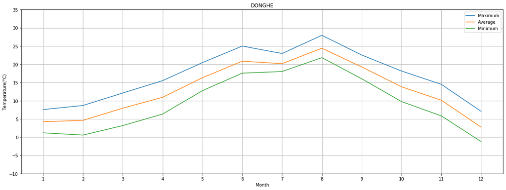

```python
plt.figure(figsize=(20, 7))
plt.xlabel('Month')
plt.ylabel('Temperature(°C)')
plt.plot(df['Month'], df['Maximum Temperature(°C)'], label='Maximum')
plt.plot(df['Month'], df['Average Temperature(°C)'], label='Average')
plt.plot(df['Month'], df['Minimum Temperature(°C)'], label='Minimum')
plt.xticks(df['Month'])
plt.title('DONGHE')
plt.ylim([-10, 35])
plt.grid(True)
plt.legend()
plt.show()
```

8월: 24.40°C, 12월: 2.74°C

##### 대관령

```python
avg_temp = [[1, daegwallyeong_avg_jan, daegwallyeong_min_jan, daegwallyeong_max_jan],
            [2, daegwallyeong_avg_feb, daegwallyeong_min_feb, daegwallyeong_max_feb],
            [3, daegwallyeong_avg_mar, daegwallyeong_min_mar, daegwallyeong_max_mar],
            [4, daegwallyeong_avg_apr, daegwallyeong_min_apr, daegwallyeong_max_apr],
            [5, daegwallyeong_avg_may, daegwallyeong_min_may, daegwallyeong_max_may],
            [6, daegwallyeong_avg_jun, daegwallyeong_min_jun, daegwallyeong_max_jun],
            [7, daegwallyeong_avg_jul, daegwallyeong_min_jul, daegwallyeong_max_jul],
            [8, daegwallyeong_avg_aug, daegwallyeong_min_aug, daegwallyeong_max_aug],
            [9, daegwallyeong_avg_sep, daegwallyeong_min_sep, daegwallyeong_max_sep],
            [10, daegwallyeong_avg_oco, daegwallyeong_min_oco, daegwallyeong_max_oco],
            [11, daegwallyeong_avg_nov, daegwallyeong_min_nov, daegwallyeong_max_nov],
            [12, daegwallyeong_avg_dec, daegwallyeong_min_dec, daegwallyeong_max_dec]]

df = pd.DataFrame(avg_temp, columns=['Month', 'Average Temperature(°C)', 'Minimum Temperature(°C)', 'Maximum Temperature(°C)'])
df
```

|  | Month | Average Temperature(°C) | Minimum Temperature(°C) | Maximum Temperature(°C) |
| --- | --- | --- | --- | --- |
| 0 | 1 | -3.17 | -7.53 | 1.57 |
| 1 | 2 | -2.70 | -8.52 | 2.48 |
| 2 | 3 | 2.13 | -4.21 | 8.42 |
| 3 | 4 | 4.81 | -1.62 | 11.09 |
| 4 | 5 | 12.78 | 7.32 | 18.59 |
| 5 | 6 | 18.73 | 13.38 | 24.33 |
| 6 | 7 | 17.86 | 13.91 | 22.27 |
| 7 | 8 | 22.15 | 19.48 | 25.77 |
| 8 | 9 | 14.69 | 10.82 | 19.05 |
| 9 | 10 | 7.86 | 2.05 | 14.61 |
| 10 | 11 | 3.38 | -2.18 | 8.92 |
| 11 | 12 | -5.40 | -10.11 | -0.42 |

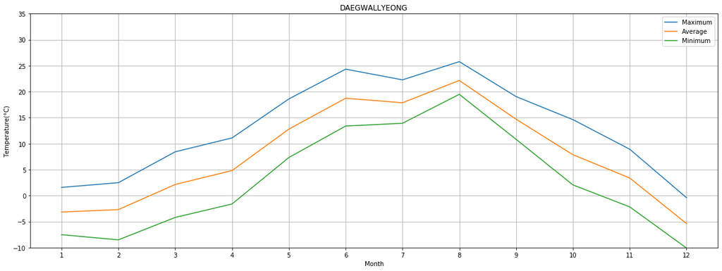

```python
plt.figure(figsize=(20, 7))
plt.xlabel('Month')
plt.ylabel('Temperature(°C)')
plt.plot(df['Month'], df['Maximum Temperature(°C)'], label='Maximum')
plt.plot(df['Month'], df['Average Temperature(°C)'], label='Average')
plt.plot(df['Month'], df['Minimum Temperature(°C)'], label='Minimum')
plt.xticks(df['Month'])
plt.title('DAEGWALLYEONG')
plt.ylim([-10, 35])
plt.grid(True)
plt.legend()
plt.show()
```

8월: 22.15°C, 12월: -5.40°C

##### 강릉

```python
avg_temp = [[1, gangneung_avg_jan, gangneung_min_jan, gangneung_max_jan],
            [2, gangneung_avg_feb, gangneung_min_feb, gangneung_max_feb],
            [3, gangneung_avg_mar, gangneung_min_mar, gangneung_max_mar],
            [4, gangneung_avg_apr, gangneung_min_apr, gangneung_max_apr],
            [5, gangneung_avg_may, gangneung_min_may, gangneung_max_may],
            [6, gangneung_avg_jun, gangneung_min_jun, gangneung_max_jun],
            [7, gangneung_avg_jul, gangneung_min_jul, gangneung_max_jul],
            [8, gangneung_avg_aug, gangneung_min_aug, gangneung_max_aug],
            [9, gangneung_avg_sep, gangneung_min_sep, gangneung_max_sep],
            [10, gangneung_avg_oco, gangneung_min_oco, gangneung_max_oco],
            [11, gangneung_avg_nov, gangneung_min_nov, gangneung_max_nov],
            [12, gangneung_avg_dec, gangneung_min_dec, gangneung_max_dec]]

df = pd.DataFrame(avg_temp, columns=['Month', 'Average Temperature(°C)', 'Minimum Temperature(°C)', 'Maximum Temperature(°C)'])
df
```

|  | Month | Average Temperature(°C) | Minimum Temperature(°C) | Maximum Temperature(°C) |
| --- | --- | --- | --- | --- |
| 0 | 1 | 4.35 | 1.71 | 8.14 |
| 1 | 2 | 5.04 | 0.90 | 9.57 |
| 2 | 3 | 8.73 | 3.64 | 13.92 |
| 3 | 4 | 11.77 | 7.11 | 16.40 |
| 4 | 5 | 18.30 | 14.27 | 22.91 |
| 5 | 6 | 24.09 | 20.05 | 28.23 |
| 6 | 7 | 22.43 | 19.61 | 25.52 |
| 7 | 8 | 27.02 | 24.09 | 30.55 |
| 8 | 9 | 20.63 | 17.23 | 24.49 |
| 9 | 10 | 15.06 | 10.78 | 20.10 |
| 10 | 11 | 10.97 | 6.74 | 15.64 |
| 11 | 12 | 3.01 | -0.78 | 7.80 |

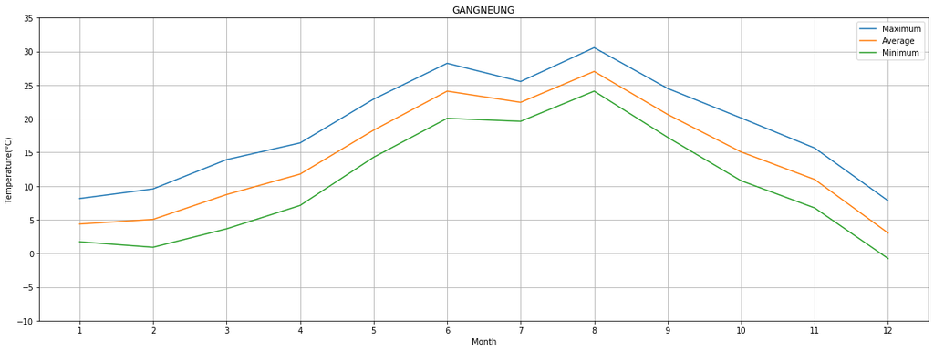

```python
plt.figure(figsize=(20, 7))
plt.xlabel('Month')
plt.ylabel('Temperature(°C)')
plt.plot(df['Month'], df['Maximum Temperature(°C)'], label='Maximum')
plt.plot(df['Month'], df['Average Temperature(°C)'], label='Average')
plt.plot(df['Month'], df['Minimum Temperature(°C)'], label='Minimum')
plt.xticks(df['Month'])
plt.title('GANGNEUNG')
plt.ylim([-10, 35])
plt.grid(True)
plt.legend()
plt.show()
```

8월: 27.02°C, 12월: 3.01°C

##### 북강릉

```python
avg_temp = [[1, bukgangneung_avg_jan, bukgangneung_min_jan, bukgangneung_max_jan],
            [2, bukgangneung_avg_feb, bukgangneung_min_feb, bukgangneung_max_feb],
            [3, bukgangneung_avg_mar, bukgangneung_min_mar, bukgangneung_max_mar],
            [4, bukgangneung_avg_apr, bukgangneung_min_apr, bukgangneung_max_apr],
            [5, bukgangneung_avg_may, bukgangneung_min_may, bukgangneung_max_may],
            [6, bukgangneung_avg_jun, bukgangneung_min_jun, bukgangneung_max_jun],
            [7, bukgangneung_avg_jul, bukgangneung_min_jul, bukgangneung_max_jul],
            [8, bukgangneung_avg_aug, bukgangneung_min_aug, bukgangneung_max_aug],
            [9, bukgangneung_avg_sep, bukgangneung_min_sep, bukgangneung_max_sep],
            [10, bukgangneung_avg_oco, bukgangneung_min_oco, bukgangneung_max_oco],
            [11, bukgangneung_avg_nov, bukgangneung_min_nov, bukgangneung_max_nov],
            [12, bukgangneung_avg_dec, bukgangneung_min_dec, bukgangneung_max_dec]]

df = pd.DataFrame(avg_temp, columns=['Month', 'Average Temperature(°C)', 'Minimum Temperature(°C)', 'Maximum Temperature(°C)'])
df
```

|  | Month | Average Temperature(°C) | Minimum Temperature(°C) | Maximum Temperature(°C) |
| --- | --- | --- | --- | --- |
| 0 | 1 | 3.50 | 0.13 | 7.37 |
| 1 | 2 | 4.15 | -0.36 | 8.65 |
| 2 | 3 | 7.96 | 2.68 | 12.77 |
| 3 | 4 | 10.82 | 5.73 | 15.76 |
| 4 | 5 | 17.04 | 12.75 | 21.92 |
| 5 | 6 | 22.18 | 17.96 | 26.53 |
| 6 | 7 | 21.00 | 18.24 | 24.10 |
| 7 | 8 | 25.41 | 22.30 | 29.28 |
| 8 | 9 | 19.39 | 15.84 | 23.31 |
| 9 | 10 | 13.71 | 9.08 | 18.78 |
| 10 | 11 | 9.88 | 5.04 | 14.57 |
| 11 | 12 | 1.69 | -3.08 | 6.61 |

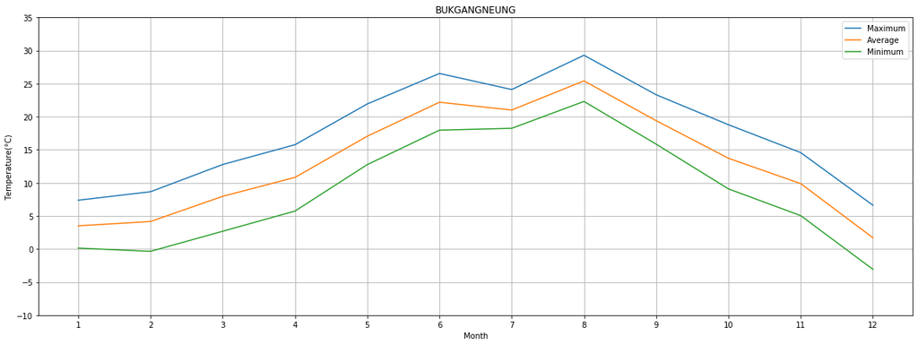

```python
plt.figure(figsize=(20, 7))
plt.xlabel('Month')
plt.ylabel('Temperature(°C)')
plt.plot(df['Month'], df['Maximum Temperature(°C)'], label='Maximum')
plt.plot(df['Month'], df['Average Temperature(°C)'], label='Average')
plt.plot(df['Month'], df['Minimum Temperature(°C)'], label='Minimum')
plt.xticks(df['Month'])
plt.title('BUKGANGNEUNG')
plt.ylim([-10, 35])
plt.grid(True)
plt.legend()
plt.show()
```

8월: 25.41°C, 12월: 1.69°C

##### 춘천

```python
avg_temp = [[1, chuncheon_avg_jan, chuncheon_min_jan, chuncheon_max_jan],
            [2, chuncheon_avg_feb, chuncheon_min_feb, chuncheon_max_feb],
            [3, chuncheon_avg_mar, chuncheon_min_mar, chuncheon_max_mar],
            [4, chuncheon_avg_apr, chuncheon_min_apr, chuncheon_max_apr],
            [5, chuncheon_avg_may, chuncheon_min_may, chuncheon_max_may],
            [6, chuncheon_avg_jun, chuncheon_min_jun, chuncheon_max_jun],
            [7, chuncheon_avg_jul, chuncheon_min_jul, chuncheon_max_jul],
            [8, chuncheon_avg_aug, chuncheon_min_aug, chuncheon_max_aug],
            [9, chuncheon_avg_sep, chuncheon_min_sep, chuncheon_max_sep],
            [10, chuncheon_avg_oco, chuncheon_min_oco, chuncheon_max_oco],
            [11, chuncheon_avg_nov, chuncheon_min_nov, chuncheon_max_nov],
            [12, chuncheon_avg_dec, chuncheon_min_dec, chuncheon_max_dec]]

df = pd.DataFrame(avg_temp, columns=['Month', 'Average Temperature(°C)', 'Minimum Temperature(°C)', 'Maximum Temperature(°C)'])
df
```

|  | Month | Average Temperature(°C) | Minimum Temperature(°C) | Maximum Temperature(°C) |
| --- | --- | --- | --- | --- |
| 0 | 1 | -0.07 | -4.60 | 5.69 |
| 1 | 2 | 1.37 | -3.78 | 7.24 |
| 2 | 3 | 6.97 | 0.10 | 13.93 |
| 3 | 4 | 10.55 | 3.20 | 17.49 |
| 4 | 5 | 18.13 | 12.92 | 23.78 |
| 5 | 6 | 24.22 | 19.16 | 29.84 |
| 6 | 7 | 23.81 | 20.13 | 28.13 |
| 7 | 8 | 26.10 | 23.61 | 29.48 |
| 8 | 9 | 19.66 | 15.84 | 24.81 |
| 9 | 10 | 11.88 | 6.20 | 19.38 |
| 10 | 11 | 6.12 | 0.77 | 12.62 |
| 11 | 12 | -2.70 | -7.89 | 3.78 |

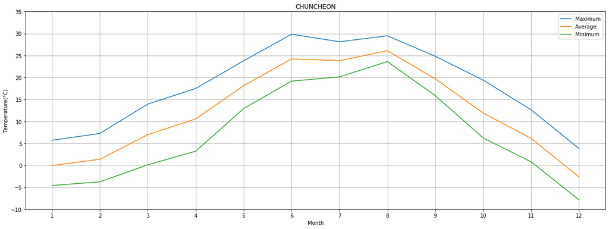

```python
plt.figure(figsize=(20, 7))
plt.xlabel('Month')
plt.ylabel('Temperature(°C)')
plt.plot(df['Month'], df['Maximum Temperature(°C)'], label='Maximum')
plt.plot(df['Month'], df['Average Temperature(°C)'], label='Average')
plt.plot(df['Month'], df['Minimum Temperature(°C)'], label='Minimum')
plt.xticks(df['Month'])
plt.title('CHUNCHEON')
plt.ylim([-10, 35])
plt.grid(True)
plt.legend()
plt.show()
```

8월: 26.10°C, 12월: -2.70°C

##### 북춘천

```python
avg_temp = [[1, bukchuncheon_avg_jan, bukchuncheon_min_jan, bukchuncheon_max_jan],
            [2, bukchuncheon_avg_feb, bukchuncheon_min_feb, bukchuncheon_max_feb],
            [3, bukchuncheon_avg_mar, bukchuncheon_min_mar, bukchuncheon_max_mar],
            [4, bukchuncheon_avg_apr, bukchuncheon_min_apr, bukchuncheon_max_apr],
            [5, bukchuncheon_avg_may, bukchuncheon_min_may, bukchuncheon_max_may],
            [6, bukchuncheon_avg_jun, bukchuncheon_min_jun, bukchuncheon_max_jun],
            [7, bukchuncheon_avg_jul, bukchuncheon_min_jul, bukchuncheon_max_jul],
            [8, bukchuncheon_avg_aug, bukchuncheon_min_aug, bukchuncheon_max_aug],
            [9, bukchuncheon_avg_sep, bukchuncheon_min_sep, bukchuncheon_max_sep],
            [10, bukchuncheon_avg_oco, bukchuncheon_min_oco, bukchuncheon_max_oco],
            [11, bukchuncheon_avg_nov, bukchuncheon_min_nov, bukchuncheon_max_nov],
            [12, bukchuncheon_avg_dec, bukchuncheon_min_dec, bukchuncheon_max_dec]]

df = pd.DataFrame(avg_temp, columns=['Month', 'Average Temperature(°C)', 'Minimum Temperature(°C)', 'Maximum Temperature(°C)'])
df
```

|  | Month | Average Temperature(°C) | Minimum Temperature(°C) | Maximum Temperature(°C) |
| --- | --- | --- | --- | --- |
| 0 | 1 | -0.73 | -5.76 | 5.58 |
| 1 | 2 | 0.66 | -5.06 | 6.94 |
| 2 | 3 | 6.14 | -1.48 | 13.53 |
| 3 | 4 | 9.67 | 1.70 | 17.38 |
| 4 | 5 | 17.41 | 11.54 | 23.73 |
| 5 | 6 | 23.45 | 17.85 | 29.55 |
| 6 | 7 | 23.29 | 19.10 | 27.91 |
| 7 | 8 | 25.62 | 22.76 | 29.57 |
| 8 | 9 | 19.03 | 14.52 | 24.87 |
| 9 | 10 | 10.94 | 4.52 | 19.07 |
| 10 | 11 | 5.31 | -0.35 | 12.12 |
| 11 | 12 | -3.63 | -9.09 | 2.95 |

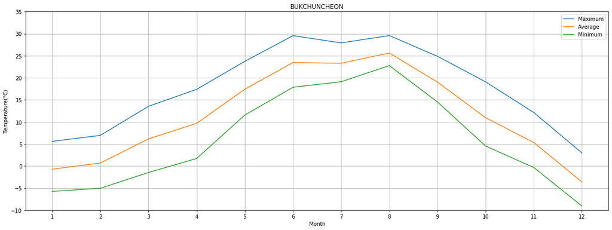

```python
plt.figure(figsize=(20, 7))
plt.xlabel('Month')
plt.ylabel('Temperature(°C)')
plt.plot(df['Month'], df['Maximum Temperature(°C)'], label='Maximum')
plt.plot(df['Month'], df['Average Temperature(°C)'], label='Average')
plt.plot(df['Month'], df['Minimum Temperature(°C)'], label='Minimum')
plt.xticks(df['Month'])
plt.title('BUKCHUNCHEON')
plt.ylim([-10, 35])
plt.grid(True)
plt.legend()
plt.show()
```

8월: 25.62°C, 12월: -3.63°C

##### 홍천

```python
avg_temp = [[1, hongcheon_avg_jan, hongcheon_min_jan, hongcheon_max_jan],
            [2, hongcheon_avg_feb, hongcheon_min_feb, hongcheon_max_feb],
            [3, hongcheon_avg_mar, hongcheon_min_mar, hongcheon_max_mar],
            [4, hongcheon_avg_apr, hongcheon_min_apr, hongcheon_max_apr],
            [5, hongcheon_avg_may, hongcheon_min_may, hongcheon_max_may],
            [6, hongcheon_avg_jun, hongcheon_min_jun, hongcheon_max_jun],
            [7, hongcheon_avg_jul, hongcheon_min_jul, hongcheon_max_jul],
            [8, hongcheon_avg_aug, hongcheon_min_aug, hongcheon_max_aug],
            [9, hongcheon_avg_sep, hongcheon_min_sep, hongcheon_max_sep],
            [10, hongcheon_avg_oco, hongcheon_min_oco, hongcheon_max_oco],
            [11, hongcheon_avg_nov, hongcheon_min_nov, hongcheon_max_nov],
            [12, hongcheon_avg_dec, hongcheon_min_dec, hongcheon_max_dec]]

df = pd.DataFrame(avg_temp, columns=['Month', 'Average Temperature(°C)', 'Minimum Temperature(°C)', 'Maximum Temperature(°C)'])
df
```

|  | Month | Average Temperature(°C) | Minimum Temperature(°C) | Maximum Temperature(°C) |
| --- | --- | --- | --- | --- |
| 0 | 1 | -0.17 | -4.85 | 6.15 |
| 1 | 2 | 1.24 | -4.10 | 7.66 |
| 2 | 3 | 6.82 | -0.49 | 14.48 |
| 3 | 4 | 10.12 | 2.53 | 17.82 |
| 4 | 5 | 17.18 | 11.61 | 23.59 |
| 5 | 6 | 23.23 | 17.90 | 29.29 |
| 6 | 7 | 22.83 | 18.95 | 27.90 |
| 7 | 8 | 25.52 | 22.60 | 29.83 |
| 8 | 9 | 18.86 | 14.62 | 24.71 |
| 9 | 10 | 11.20 | 5.32 | 19.24 |
| 10 | 11 | 5.59 | 0.35 | 12.30 |
| 11 | 12 | -3.27 | -8.26 | 3.23 |

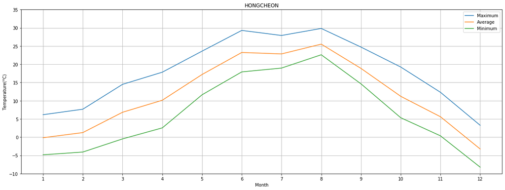

```python
plt.figure(figsize=(20, 7))
plt.xlabel('Month')
plt.ylabel('Temperature(°C)')
plt.plot(df['Month'], df['Maximum Temperature(°C)'], label='Maximum')
plt.plot(df['Month'], df['Average Temperature(°C)'], label='Average')
plt.plot(df['Month'], df['Minimum Temperature(°C)'], label='Minimum')
plt.xticks(df['Month'])
plt.title('HONGCHEON')
plt.ylim([-10, 35])
plt.grid(True)
plt.legend()
plt.show()
```

8월: 25.52°C, 12월: -3.27°C

##### 태백

```python
avg_temp = [[1, taebaek_avg_jan, taebaek_min_jan, taebaek_max_jan], [2, taebaek_avg_feb, taebaek_min_feb, taebaek_max_feb],
            [3, taebaek_avg_mar, taebaek_min_mar, taebaek_max_mar], [4, taebaek_avg_apr, taebaek_min_apr, taebaek_max_apr],
            [5, taebaek_avg_may, taebaek_min_may, taebaek_max_may], [6, taebaek_avg_jun, taebaek_min_jun, taebaek_max_jun],
            [7, taebaek_avg_jul, taebaek_min_jul, taebaek_max_jul], [8, taebaek_avg_aug, taebaek_min_aug, taebaek_max_aug],
            [9, taebaek_avg_sep, taebaek_min_sep, taebaek_max_sep], [10, taebaek_avg_oco, taebaek_min_oco, taebaek_max_oco],
            [11, taebaek_avg_nov, taebaek_min_nov, taebaek_max_nov], [12, taebaek_avg_dec, taebaek_min_dec, taebaek_max_dec]]

df = pd.DataFrame(avg_temp, columns=['Month', 'Average Temperature(°C)', 'Minimum Temperature(°C)', 'Maximum Temperature(°C)'])
df
```

|  | Month | Average Temperature(°C) | Minimum Temperature(°C) | Maximum Temperature(°C) |
| --- | --- | --- | --- | --- |
| 0 | 1 | -1.34 | -5.21 | 3.44 |
| 1 | 2 | -0.58 | -5.86 | 4.90 |
| 2 | 3 | 4.22 | -1.95 | 10.61 |
| 3 | 4 | 6.69 | 0.75 | 13.00 |
| 4 | 5 | 14.84 | 9.10 | 21.32 |
| 5 | 6 | 20.59 | 15.21 | 26.77 |
| 6 | 7 | 18.91 | 15.38 | 23.31 |
| 7 | 8 | 23.26 | 20.11 | 27.52 |
| 8 | 9 | 15.83 | 12.39 | 20.10 |
| 9 | 10 | 9.80 | 4.56 | 16.17 |
| 10 | 11 | 5.63 | 0.73 | 10.95 |
| 11 | 12 | -2.61 | -6.91 | 2.19 |

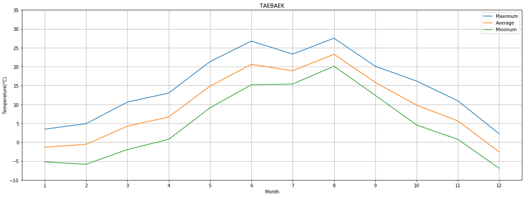

```python
plt.figure(figsize=(20, 7))
plt.xlabel('Month')
plt.ylabel('Temperature(°C)')
plt.plot(df['Month'], df['Maximum Temperature(°C)'], label='Maximum')
plt.plot(df['Month'], df['Average Temperature(°C)'], label='Average')
plt.plot(df['Month'], df['Minimum Temperature(°C)'], label='Minimum')
plt.xticks(df['Month'])
plt.title('TAEBAEK')
plt.ylim([-10, 35])
plt.grid(True)
plt.legend()
plt.show()
```

8월: 23.26°C, 12월: -2.61°C

##### 철원

```python
avg_temp = [[1, cheorwon_avg_jan, cheorwon_min_jan, cheorwon_max_jan], [2, cheorwon_avg_feb, cheorwon_min_feb, cheorwon_max_feb],
            [3, cheorwon_avg_mar, cheorwon_min_mar, cheorwon_max_mar], [4, cheorwon_avg_apr, cheorwon_min_apr, cheorwon_max_apr],
            [5, cheorwon_avg_may, cheorwon_min_may, cheorwon_max_may], [6, cheorwon_avg_jun, cheorwon_min_jun, cheorwon_max_jun],
            [7, cheorwon_avg_jul, cheorwon_min_jul, cheorwon_max_jul], [8, cheorwon_avg_aug, cheorwon_min_aug, cheorwon_max_aug],
            [9, cheorwon_avg_sep, cheorwon_min_sep, cheorwon_max_sep], [10, cheorwon_avg_oco, cheorwon_min_oco, cheorwon_max_oco],
            [11, cheorwon_avg_nov, cheorwon_min_nov, cheorwon_max_nov], [12, cheorwon_avg_dec, cheorwon_min_dec, cheorwon_max_dec]]

df = pd.DataFrame(avg_temp, columns=['Month', 'Average Temperature(°C)', 'Minimum Temperature(°C)', 'Maximum Temperature(°C)'])
df
```

|  | Month | Average Temperature(°C) | Minimum Temperature(°C) | Maximum Temperature(°C) |
| --- | --- | --- | --- | --- |
| 0 | 1 | -1.19 | -6.24 | 4.79 |
| 1 | 2 | 0.01 | -5.41 | 6.01 |
| 2 | 3 | 5.50 | -2.21 | 12.57 |
| 3 | 4 | 9.14 | 1.13 | 16.39 |
| 4 | 5 | 16.89 | 11.57 | 22.64 |
| 5 | 6 | 22.51 | 17.36 | 28.21 |
| 6 | 7 | 22.75 | 18.94 | 27.54 |
| 7 | 8 | 25.10 | 22.27 | 28.65 |
| 8 | 9 | 18.77 | 14.12 | 24.37 |
| 9 | 10 | 10.85 | 3.95 | 18.53 |
| 10 | 11 | 4.98 | -0.97 | 11.42 |
| 11 | 12 | -3.94 | -9.72 | 2.14 |

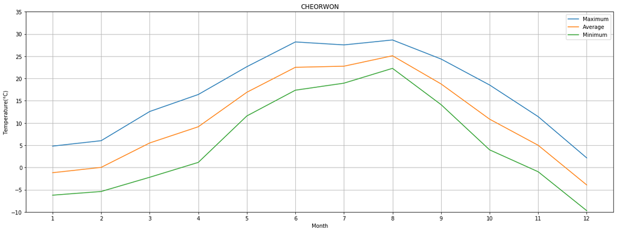

```python
plt.figure(figsize=(20, 7))
plt.xlabel('Month')
plt.ylabel('Temperature(°C)')
plt.plot(df['Month'], df['Maximum Temperature(°C)'], label='Maximum')
plt.plot(df['Month'], df['Average Temperature(°C)'], label='Average')
plt.plot(df['Month'], df['Minimum Temperature(°C)'], label='Minimum')
plt.xticks(df['Month'])
plt.title('CHEORWON')
plt.ylim([-10, 35])
plt.grid(True)
plt.legend()
plt.show()
```

8월: 25.10°C, 12월: -3.94°C

##### 정선

```python
avg_temp = [[1, jeongseon_avg_jan, jeongseon_min_jan, jeongseon_max_jan],
            [2, jeongseon_avg_feb, jeongseon_min_feb, jeongseon_max_feb],
            [3, jeongseon_avg_mar, jeongseon_min_mar, jeongseon_max_mar],
            [4, jeongseon_avg_apr, jeongseon_min_apr, jeongseon_max_apr],
            [5, jeongseon_avg_may, jeongseon_min_may, jeongseon_max_may],
            [6, jeongseon_avg_jun, jeongseon_min_jun, jeongseon_max_jun],
            [7, jeongseon_avg_jul, jeongseon_min_jul, jeongseon_max_jul],
            [8, jeongseon_avg_aug, jeongseon_min_aug, jeongseon_max_aug],
            [9, jeongseon_avg_sep, jeongseon_min_sep, jeongseon_max_sep],
            [10, jeongseon_avg_oco, jeongseon_min_oco, jeongseon_max_oco],
            [11, jeongseon_avg_nov, jeongseon_min_nov, jeongseon_max_nov],
            [12, jeongseon_avg_dec, jeongseon_min_dec, jeongseon_max_dec]]

df = pd.DataFrame(avg_temp, columns=['Month', 'Average Temperature(°C)', 'Minimum Temperature(°C)', 'Maximum Temperature(°C)'])
df
```

|  | Month | Average Temperature(°C) | Minimum Temperature(°C) | Maximum Temperature(°C) |
| --- | --- | --- | --- | --- |
| 0 | 1 | -0.49 | -4.81 | 5.32 |
| 1 | 2 | 0.86 | -4.26 | 6.90 |
| 2 | 3 | 6.09 | -0.57 | 13.42 |
| 3 | 4 | 8.84 | 2.20 | 16.11 |
| 4 | 5 | 16.46 | 10.93 | 23.37 |
| 5 | 6 | 22.33 | 16.66 | 29.29 |
| 6 | 7 | 21.78 | 17.81 | 27.51 |
| 7 | 8 | 24.51 | 21.25 | 29.23 |
| 8 | 9 | 18.06 | 14.52 | 23.36 |
| 9 | 10 | 11.23 | 6.00 | 18.60 |
| 10 | 11 | 5.95 | 0.67 | 12.38 |
| 11 | 12 | -3.12 | -8.36 | 3.07 |

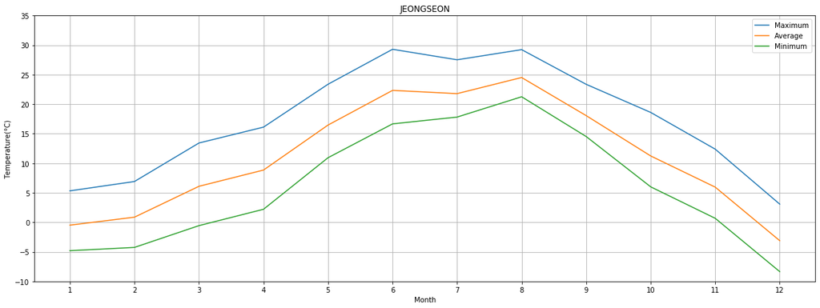

```python
plt.figure(figsize=(20, 7))
plt.xlabel('Month')
plt.ylabel('Temperature(°C)')
plt.plot(df['Month'], df['Maximum Temperature(°C)'], label='Maximum')
plt.plot(df['Month'], df['Average Temperature(°C)'], label='Average')
plt.plot(df['Month'], df['Minimum Temperature(°C)'], label='Minimum')
plt.xticks(df['Month'])
plt.title('JEONGSEON')
plt.ylim([-10, 35])
plt.grid(True)
plt.legend()
plt.show()
```

8월: 24.51°C, 12월: -3.12°C

##### 인제

```python
avg_temp = [[1, inje_avg_jan, inje_min_jan, inje_max_jan], [2, inje_avg_feb, inje_min_feb, inje_max_feb],
            [3, inje_avg_mar, inje_min_mar, inje_max_mar], [4, inje_avg_apr, inje_min_apr, inje_max_apr],
            [5, inje_avg_may, inje_min_may, inje_max_may], [6, inje_avg_jun, inje_min_jun, inje_max_jun],
            [7, inje_avg_jul, inje_min_jul, inje_max_jul], [8, inje_avg_aug, inje_min_aug, inje_max_aug],
            [9, inje_avg_sep, inje_min_sep, inje_max_sep], [10, inje_avg_oco, inje_min_oco, inje_max_oco],
            [11, inje_avg_nov, inje_min_nov, inje_max_nov], [12, inje_avg_dec, inje_min_dec, inje_max_dec]]

df = pd.DataFrame(avg_temp, columns=['Month', 'Average Temperature(°C)', 'Minimum Temperature(°C)', 'Maximum Temperature(°C)'])
df
```

|  | Month | Average Temperature(°C) | Minimum Temperature(°C) | Maximum Temperature(°C) |
| --- | --- | --- | --- | --- |
| 0 | 1 | -0.07 | -4.53 | 5.85 |
| 1 | 2 | 0.80 | -4.44 | 6.81 |
| 2 | 3 | 5.80 | -0.98 | 13.08 |
| 3 | 4 | 9.00 | 2.06 | 15.98 |
| 4 | 5 | 16.59 | 11.32 | 22.86 |
| 5 | 6 | 22.58 | 17.36 | 28.63 |
| 6 | 7 | 22.13 | 18.29 | 27.18 |
| 7 | 8 | 24.92 | 22.22 | 28.81 |
| 8 | 9 | 18.48 | 14.76 | 23.80 |
| 9 | 10 | 10.99 | 5.28 | 18.60 |
| 10 | 11 | 5.83 | 0.41 | 12.23 |
| 11 | 12 | -2.66 | -7.88 | 3.18 |

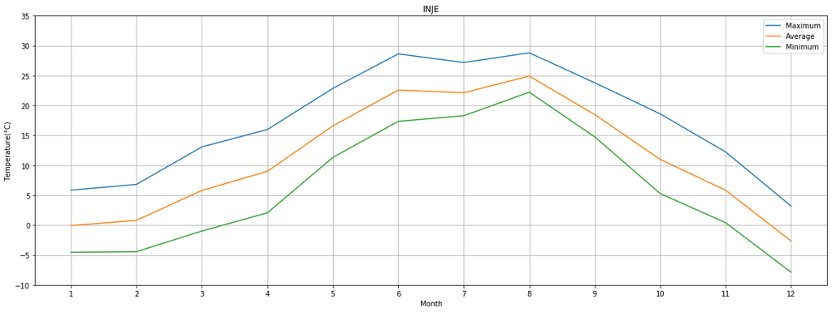

```python
plt.figure(figsize=(20, 7))
plt.xlabel('Month')
plt.ylabel('Temperature(°C)')
plt.plot(df['Month'], df['Maximum Temperature(°C)'], label='Maximum')
plt.plot(df['Month'], df['Average Temperature(°C)'], label='Average')
plt.plot(df['Month'], df['Minimum Temperature(°C)'], label='Minimum')
plt.xticks(df['Month'])
plt.title('INJE')
plt.ylim([-10, 35])
plt.grid(True)
plt.legend()
plt.show()
```

8월: 24.92°C, 12월: -2.66°C

##### 원주

```python
avg_temp = [[1, wonju_avg_jan, wonju_min_jan, wonju_max_jan], [2, wonju_avg_feb, wonju_min_feb, wonju_max_feb],
            [3, wonju_avg_mar, wonju_min_mar, wonju_max_mar], [4, wonju_avg_apr, wonju_min_apr, wonju_max_apr],
            [5, wonju_avg_may, wonju_min_may, wonju_max_may], [6, wonju_avg_jun, wonju_min_jun, wonju_max_jun],
            [7, wonju_avg_jul, wonju_min_jul, wonju_max_jul], [8, wonju_avg_aug, wonju_min_aug, wonju_max_aug],
            [9, wonju_avg_sep, wonju_min_sep, wonju_max_sep], [10, wonju_avg_oco, wonju_min_oco, wonju_max_oco],
            [11, wonju_avg_nov, wonju_min_nov, wonju_max_nov], [12, wonju_avg_dec, wonju_min_dec, wonju_max_dec]]

df = pd.DataFrame(avg_temp, columns=['Month', 'Average Temperature(°C)', 'Minimum Temperature(°C)', 'Maximum Temperature(°C)'])
df
```

|  | Month | Average Temperature(°C) | Minimum Temperature(°C) | Maximum Temperature(°C) |
| --- | --- | --- | --- | --- |
| 0 | 1 | 1.23 | -2.72 | 6.03 |
| 1 | 2 | 2.54 | -1.91 | 7.51 |
| 2 | 3 | 7.77 | 1.70 | 13.95 |
| 3 | 4 | 10.95 | 4.68 | 17.19 |
| 4 | 5 | 18.20 | 13.26 | 23.52 |
| 5 | 6 | 24.05 | 19.52 | 29.21 |
| 6 | 7 | 23.68 | 20.27 | 27.93 |
| 7 | 8 | 26.14 | 23.30 | 30.03 |
| 8 | 9 | 19.90 | 16.02 | 24.66 |
| 9 | 10 | 12.71 | 7.35 | 18.90 |
| 10 | 11 | 7.33 | 2.46 | 12.73 |
| 11 | 12 | -1.44 | -5.79 | 3.62 |

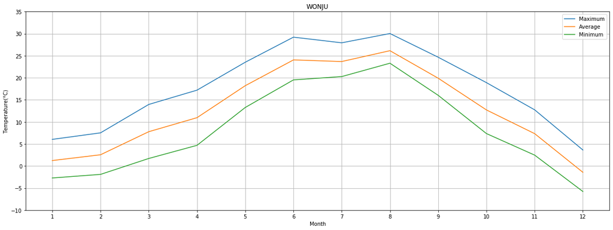

```python
plt.figure(figsize=(20, 7))
plt.xlabel('Month')
plt.ylabel('Temperature(°C)')
plt.plot(df['Month'], df['Maximum Temperature(°C)'], label='Maximum')
plt.plot(df['Month'], df['Average Temperature(°C)'], label='Average')
plt.plot(df['Month'], df['Minimum Temperature(°C)'], label='Minimum')
plt.xticks(df['Month'])
plt.title('WONJU')
plt.ylim([-10, 35])
plt.grid(True)
plt.legend()
plt.show()
```

##### 영월

```python
avg_temp = [[1, yeongwol_avg_jan, yeongwol_min_jan, yeongwol_max_jan], [2, yeongwol_avg_feb, yeongwol_min_feb, yeongwol_max_feb],
            [3, yeongwol_avg_mar, yeongwol_min_mar, yeongwol_max_mar], [4, yeongwol_avg_apr, yeongwol_min_apr, yeongwol_max_apr],
            [5, yeongwol_avg_may, yeongwol_min_may, yeongwol_max_may], [6, yeongwol_avg_jun, yeongwol_min_jun, yeongwol_max_jun],
            [7, yeongwol_avg_jul, yeongwol_min_jul, yeongwol_max_jul], [8, yeongwol_avg_aug, yeongwol_min_aug, yeongwol_max_aug],
            [9, yeongwol_avg_sep, yeongwol_min_sep, yeongwol_max_sep], [10, yeongwol_avg_oco, yeongwol_min_oco, yeongwol_max_oco],
            [11, yeongwol_avg_nov, yeongwol_min_nov, yeongwol_max_nov], [12, yeongwol_avg_dec, yeongwol_min_dec, yeongwol_max_dec]]

df = pd.DataFrame(avg_temp, columns=['Month', 'Average Temperature(°C)', 'Minimum Temperature(°C)', 'Maximum Temperature(°C)'])
df
```

|  | Month | Average Temperature(°C) | Minimum Temperature(°C) | Maximum Temperature(°C) |
| --- | --- | --- | --- | --- |
| 0 | 1 | 0.80 | -3.82 | 6.80 |
| 1 | 2 | 2.12 | -3.18 | 8.21 |
| 2 | 3 | 7.38 | 0.38 | 14.61 |
| 3 | 4 | 10.34 | 3.02 | 18.04 |
| 4 | 5 | 17.20 | 11.60 | 24.28 |
| 5 | 6 | 22.90 | 17.40 | 29.76 |
| 6 | 7 | 22.54 | 18.76 | 27.94 |
| 7 | 8 | 25.01 | 22.18 | 29.77 |
| 8 | 9 | 18.75 | 14.81 | 24.38 |
| 9 | 10 | 11.79 | 6.05 | 19.41 |
| 10 | 11 | 6.81 | 1.29 | 13.51 |
| 11 | 12 | -2.20 | -7.63 | 4.19 |

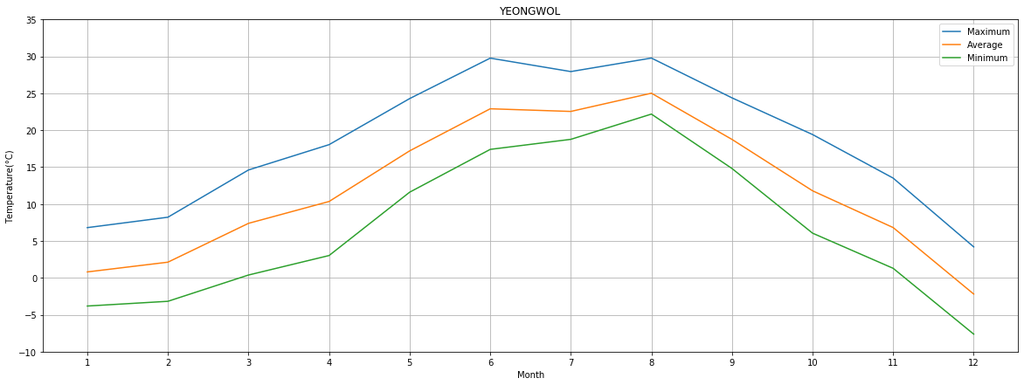

```python
plt.figure(figsize=(20, 7))
plt.xlabel('Month')
plt.ylabel('Temperature(°C)')
plt.plot(df['Month'], df['Maximum Temperature(°C)'], label='Maximum')
plt.plot(df['Month'], df['Average Temperature(°C)'], label='Average')
plt.plot(df['Month'], df['Minimum Temperature(°C)'], label='Minimum')
plt.xticks(df['Month'])
plt.title('YEONGWOL')
plt.ylim([-10, 35])
plt.grid(True)
plt.legend()
plt.show()
```

8월: 25.01°C, 12월: -2.20°C

##### 속초

```python
avg_temp = [[1, sokcho_avg_jan, sokcho_min_jan, sokcho_max_jan], [2, sokcho_avg_feb, sokcho_min_feb, sokcho_max_feb],
            [3, sokcho_avg_mar, sokcho_min_mar, sokcho_max_mar], [4, sokcho_avg_apr, sokcho_min_apr, sokcho_max_apr],
            [5, sokcho_avg_may, sokcho_min_may, sokcho_max_may], [6, sokcho_avg_jun, sokcho_min_jun, sokcho_max_jun],
            [7, sokcho_avg_jul, sokcho_min_jul, sokcho_max_jul], [8, sokcho_avg_aug, sokcho_min_aug, sokcho_max_aug],
            [9, sokcho_avg_sep, sokcho_min_sep, sokcho_max_sep], [10, sokcho_avg_oco, sokcho_min_oco, sokcho_max_oco],
            [11, sokcho_avg_nov, sokcho_min_nov, sokcho_max_nov], [12, sokcho_avg_dec, sokcho_min_dec, sokcho_max_dec]]

df = pd.DataFrame(avg_temp, columns=['Month', 'Average Temperature(°C)', 'Minimum Temperature(°C)', 'Maximum Temperature(°C)'])
df
```

[output not shown]

```python
plt.figure(figsize=(20, 7))
plt.xlabel('Month')
plt.ylabel('Temperature(°C)')
plt.plot(df['Month'], df['Maximum Temperature(°C)'], label='Maximum')
plt.plot(df['Month'], df['Average Temperature(°C)'], label='Average')
plt.plot(df['Month'], df['Minimum Temperature(°C)'], label='Minimum')
plt.xticks(df['Month'])
plt.title('SOKCHO')
plt.ylim([-10, 35])
plt.grid(True)
plt.legend()
plt.show()
```

[output not shown]

8월: 25.68°C, 12월: 1.84°C

##### 대구

```python
avg_temp = [[1, daegu_avg_jan, daegu_min_jan, daegu_max_jan], [2, daegu_avg_feb, daegu_min_feb, daegu_max_feb],
            [3, daegu_avg_mar, daegu_min_mar, daegu_max_mar], [4, daegu_avg_apr, daegu_min_apr, daegu_max_apr],
            [5, daegu_avg_may, daegu_min_may, daegu_max_may], [6, daegu_avg_jun, daegu_min_jun, daegu_max_jun],
            [7, daegu_avg_jul, daegu_min_jul, daegu_max_jul], [8, daegu_avg_aug, daegu_min_aug, daegu_max_aug],
            [9, daegu_avg_sep, daegu_min_sep, daegu_max_sep], [10, daegu_avg_oco, daegu_min_oco, daegu_max_oco],
            [11, daegu_avg_nov, daegu_min_nov, daegu_max_nov], [12, daegu_avg_dec, daegu_min_dec, daegu_max_dec]]

df = pd.DataFrame(avg_temp, columns=['Month', 'Average Temperature(°C)', 'Minimum Temperature(°C)', 'Maximum Temperature(°C)'])
df
```

[output not shown]

```python
plt.figure(figsize=(20, 7))
plt.xlabel('Month')
plt.ylabel('Temperature(°C)')
plt.plot(df['Month'], df['Maximum Temperature(°C)'], label='Maximum')
plt.plot(df['Month'], df['Average Temperature(°C)'], label='Average')
plt.plot(df['Month'], df['Minimum Temperature(°C)'], label='Minimum')
plt.xticks(df['Month'])
plt.title('DAEGU')
plt.ylim([-10, 35])
plt.grid(True)
plt.legend()
plt.show()
```

[output not shown]

8월: 28.55°C, 12월: 1.55°C